# Task3,4,5- Feature Engineering, Data Visualization, Modeling and Cutoff Strategy

```python
import pandas as pd
import numpy as np
pd.set_option('display.max_rows', None)
```

```python
import pandas as pd
import numpy as np
import os

from sklearn.linear_model import LinearRegression
from sklearn.model_selection import cross_val_score
from sklearn.model_selection import RepeatedStratifiedKFold, StratifiedKFold, GridSearchCV
from sklearn.metrics import fbeta_score
from sklearn.metrics import make_scorer
from sklearn import metrics
from matplotlib import pyplot
from sklearn.linear_model import LogisticRegression

from sklearn.ensemble import RandomForestClassifier
from sklearn.tree import DecisionTreeClassifier
from imblearn.over_sampling import SMOTE


import statsmodels.api as sm
from sklearn.metrics import roc_auc_score, roc_curve, precision_recall_curve, auc, accuracy_score
from sklearn.model_selection import train_test_split
from sklearn.linear_model import LogisticRegression
from sklearn.metrics import roc_auc_score
from sklearn.metrics import roc_auc_score, roc_curve, precision_recall_curve, auc
from sklearn.discriminant_analysis import LinearDiscriminantAnalysis
from scipy.stats import pearsonr
from sklearn.feature_selection import RFECV
from imblearn.over_sampling import BorderlineSMOTE

import xgboost as xgb
from sklearn.metrics import mean_squared_error
from imblearn.ensemble import BalancedRandomForestClassifier
from sklearn.metrics import  classification_report, confusion_matrix
from sklearn.model_selection import cross_validate
from statistics import mean
import pickle

from imblearn.under_sampling import RandomUnderSampler, NearMiss
from collections import Counter

import matplotlib.pyplot as plt
import seaborn as sns
%matplotlib inline
# pd.set_option('max_rows', None)
# pd.set_option('max_columns', None)
# pd.set_option('max_colwidth', None)
# pd.set_option('display.float_format', lambda x: '%.3f' % x)

%run utils.ipynb
```

```python
%run utils.ipynb
```

```python
df = pd.read_excel('customer_profile_sql.xlsx')
df.drop(columns=['Unnamed: 0'], inplace=True)
```

```python
df.head()
```

|  | application_id | customer_id_str | dob | Age | loan_purpose | loan_purpose_desc | address_provinsi | marital_status | dependent | job_type | ... | dpd_calculated_max | GBFlag | Min_Loan_Amount | Max_Loan_Amount | Avg_Loan_Amount | Defaulted_Loans | Total_Amount_Disbursed | Total_Amount_Recovered | Recovery_Rate | GBFlag_cus |
| --- | --- | --- | --- | --- | --- | --- | --- | --- | --- | --- | --- | --- | --- | --- | --- | --- | --- | --- | --- | --- | --- |
| 0 | 2004025560801 | 2.003023e+12 | 1984-04-18 | 39.0 | Modal usaha | memulai usaha online berjualan masker online | Dki Jakarta | Menikah | 1.0 | NaN | ... | 30.0 | Good | 800000.0 | 6000000.0 | 2.200000e+06 | 0.0 | 8800000.0 | 16484000.0 | 187.318182 | Good |
| 1 | 2004025574618 | 2.003023e+12 | 1993-12-19 | 30.0 | Renovasi Rumah | tujuan untuk renovasi rumah dan lain lain | DKI Jakarta | Lajang | 0.0 | Pegawai swasta | ... | 30.0 | Good | 500000.0 | 2500000.0 | 1.875000e+06 | 0.0 | 7500000.0 | 5784000.0 | 77.120000 | Good |
| 2 | 2004025576523 | 2.003023e+12 | 1986-06-08 | 37.0 | NaN | untuk menambah modal untuk divisi baru cargo | Jawa Timur | Menikah | 3.0 | Pengusaha | ... | 28.0 | Good | 500000.0 | 2000000.0 | 1.333333e+06 | 0.0 | 8000000.0 | 8256000.0 | 103.200000 | Good |
| 3 | 2004025579060 | 2.003023e+12 | 1987-10-01 | 36.0 | Biaya kesehatan | untuk membantu saya dalam kendala biaya keseha... | DKI Jakarta | Menikah | 1.0 | Pegawai swasta | ... | 28.0 | Good | 300000.0 | 4000000.0 | 1.088889e+06 | 0.0 | 9800000.0 | 8900000.0 | 90.816327 | Good |
| 4 | 2004025589544 | 2.003024e+12 | 1991-08-27 | 32.0 | Modal usaha | modal usaha roti bakar dan cireng isi pisang k... | NaN | Menikah | 0.0 | Pegawai swasta | ... | 30.0 | Good | 500000.0 | 2000000.0 | 8.750000e+05 | 1.0 | 3500000.0 | 1566000.0 | 44.742857 | Bad |

5 rows × 29 columns

##### PART 2 Feature Engineering

we have features related to:

- Numberical Data
1. Age
2. Dependents
3. Average Loan Amount
4. Total Loans
5. Loan Duration (We tend to not use these kind of variables , as it can be handle with Policy Rules for the sake of exercise considering this variable)
- Application data
1. Marital Status
2. Job Type
3. Job Industry
4. Loan Purpose
5. Adresss_province

Before Proceed to Modeling, it is very important to fine tune your variables that will help us later to improve model performance. fine tuning includes adjustment of outliers, replacement of NaN or negative values.

One thing to make sure here is your coarse classing should follow business rules of the product.

```python
# Drop rows where 'GBFlag_cus' column has NaN values
df = df.dropna(subset=['GBFlag_cus'])
```

```python
# Define a dictionary with the original phrases and their English translations
translation_dict = {
    'Modal usaha': 'Business capital',
    'Renovasi Rumah': 'Home renovation',
    'Biaya kesehatan': 'Healthcare costs',
    'Biaya pendidikan': 'Educational expenses',
    'Membeli elektronik': 'Buying electronics',
    'Kebutuhan sehari-hari': 'Daily necessities',
    'Biaya liburan / umroh': 'Holiday expenses / Umrah',
    'Membayar hutang lainnya': 'Paying other debts',
    'Belanja online': 'Online shopping',
    'Membeli kendaraan': 'Buying a vehicle',
    'Transfer ke Keluarga/Teman': 'Transfer to Family/Friends'
}

# Replace the phrases in the 'loan_purpose' column with their English translations
df['loan_purpose'] = df['loan_purpose'].replace(translation_dict)
df['loan_purpose'] = df['loan_purpose'].fillna('Miscellaneous')
df['loan_purpose'].unique()
```

```
array(['Business capital', 'Home renovation', 'Miscellaneous',
       'Healthcare costs', 'Educational expenses', 'Buying electronics',
       'Daily necessities', 'Holiday expenses / Umrah',
       'Paying other debts', 'Online shopping', 'Buying a vehicle',
       'Transfer to Family/Friends'], dtype=object)
```

##### Variance Threshold

Variance Threshold is a feature selector that removes all the low variance features from the dataset that are of no great use in modeling. It looks only at the features (x), not the desired outputs/target (y), and can thus be used for unsupervised learning.

- High Variance in predictors: Good Indication
- Low Variance predictors: Not good for model We can drop constant features using Sklearn’s Variance Threshold. Default Value of Threshold is 0

```
-  If Variance Threshold = 0 (Remove Constant Features )
-  If Variance Threshold > 0 (Remove Quasi-Constant Features )
```

- Constant Feature: Same value in all the records.
- Quasi Constant Feature: One of the values is dominant 99.9%.

```python
from sklearn.feature_selection import VarianceThreshold
```

```python
# select numerical variables
data_universe_num = df.select_dtypes(include = 'number')
print('data_universe_num', data_universe_num.shape)
```

```
data_universe_num (496, 19)
```

```python
# Check for zero variance or degenerate variables and drop them i.e if a variable has variance less than the threshold
# drop them otherwise keep them

## Specify variance of 10%
near_zero = VarianceThreshold(threshold = 0.10)
near_zero.fit_transform(data_universe_num)

# Get column index of the variable with variance > 10%
highvar = near_zero.get_support(indices=True)

### Get columns in a list
variance_relevant_variables = data_universe_num.columns[highvar].tolist()

# Zero variance variables
zero_variance_variables = [col for col in data_universe_num.columns.tolist() if col not in variance_relevant_variables]

print('variance_relevant_variables', len(variance_relevant_variables))
print('zero_variance_variables', len(zero_variance_variables))
```

```
variance_relevant_variables 19
zero_variance_variables 0
```

Fortunately, we have no variables with zero variance so we are not dropping any variables now

```python
variance_relevant_variables
```

```
['application_id',
 'customer_id_str',
 'Age',
 'dependent',
 'loan_id',
 'loan_amount',
 'recovered_amount',
 'loan_duration',
 'installment_amount',
 'loan_num',
 'total_loans',
 'dpd_calculated_max',
 'Min_Loan_Amount',
 'Max_Loan_Amount',
 'Avg_Loan_Amount',
 'Defaulted_Loans',
 'Total_Amount_Disbursed',
 'Total_Amount_Recovered',
 'Recovery_Rate']
```

```python
df.drop(columns = zero_variance_variables, inplace=True)
df.shape
```

```
(496, 29)
```

```python
print(df.select_dtypes(include=['object']).dtypes)
```

```
dob                  object
loan_purpose         object
loan_purpose_desc    object
address_provinsi     object
marital_status       object
job_type             object
job_industry         object
Disb_Month           object
GBFlag               object
GBFlag_cus           object
dtype: object
```

##### 1.Fine Classing & Coarse Classing

For Application Variables we will try to bin them with respect to their nature.

Conventionally, we only try to manage 4/5 bins at max. Reason is more the bins the more your model is going to complex that will relate to overfitting eventually. lesser bins like 1/2 we need to avoid so model should not oversimplify

```python
# Regroup Educational status
df['loan_purpose_binned'] = np.where(df['loan_purpose'].isin(['Buying electronics', 'Buying a vehicle', 'Home renovation', 'Online shopping']), 'LifeStyle Expenses',
    np.where(df['loan_purpose'].isin(['Paying other debts', 'Miscellaneous']), 'Other Expenses',
    np.where(df['loan_purpose'].isin(['Daily necessities', 'Educational expenses']), 'Running Expenses',
    np.where(df['loan_purpose'].isin(['Business capital', 'Holiday expenses / Umrah', 'Transfer to Family/Friends']), 'Investment/Payment Expenses',
    np.where(df['loan_purpose'].isin(['Healthcare costs	']), 'Health Expenses', df['loan_purpose'])))))

df['loan_purpose_binned'].value_counts()
```

```
loan_purpose_binned
Investment/Payment Expenses    160
Running Expenses               138
LifeStyle Expenses             107
Other Expenses                  65
Healthcare costs                26
Name: count, dtype: int64
```

```python
loan_purpose_bad = pd.crosstab(df['loan_purpose_binned'], df['GBFlag_cus'])
loan_purpose_bad['Bad Rate(%)']= loan_purpose_bad['Bad']/loan_purpose_bad.sum(axis=1) *100
loan_purpose_bad.sort_values('Bad Rate(%)', ascending=False)
```

| GBFlag_cus loan_purpose_binned | Bad | Good | Bad Rate(%) |
| --- | --- | --- | --- |
| Healthcare costs | 14 | 12 | 53.846154 |
| Running Expenses | 74 | 64 | 53.623188 |
| Other Expenses | 33 | 32 | 50.769231 |
| Investment/Payment Expenses | 73 | 87 | 45.625000 |
| LifeStyle Expenses | 44 | 63 | 41.121495 |

```python
df['address_provinsi'] = df['address_provinsi'].fillna("Other Regions")
```

```python
# Convert 'address_provinsi' to lowercase and copy the unique values
df['address_provinsi'] = df['address_provinsi'].str.lower()

# Get the unique values in the 'address_provinsi' column after conversion to lowercase
unique_provinsi_lower = df['address_provinsi'].unique()

# Display the unique lowercase province names
print(list(unique_provinsi_lower))
```

```
['dki jakarta', 'jawa timur', 'other regions', 'banten', 'jawa barat', 'nanggroe aceh darussalam (nad)', 'sumatera utara', 'sulawesi selatan', 'maluku', 'bali', 'kalimantan timur', 'kepulauan riau', 'jawa tengah', 'papua barat', 'kalimantan utara', 'lampung', 'riau', 'bengkulu', 'di yogyakarta', 'su…
```

```python
# Mapping of provinces to regions
province_to_region = {
    'dki jakarta': 'Jakarta (Special Region)',
    'jawa barat': 'West Java',
    'jawa tengah': 'Central Java',
    'di yogyakarta': 'Papua and Maluku and Yogyakarta',
    'jawa timur': 'East Java',
    'banten': 'Banten',
    'nanggroe aceh darussalam (nad)': 'Sumatra',
    'sumatera utara': 'Sumatra',
    'sumatera barat': 'Sumatra',
    'riau': 'Sumatra',
    'bengkulu': 'Sumatra',
    'lampung': 'Sumatra',
    'sumatera selatan': 'Sumatra',
    'kepulauan riau': 'Sumatra',
    'kalimantan barat': 'Kalimantan',
    'kalimantan tengah': 'Kalimantan',
    'kalimantan selatan': 'Kalimantan',
    'kalimantan timur': 'Kalimantan',
    'kalimantan utara': 'Kalimantan',
    'sulawesi utara': 'Sulawesi',
    'sulawesi selatan': 'Sulawesi',
    'sulawesi tenggara': 'Sulawesi',
    'papua': 'Papua and Maluku and Yogyakarta',
    'papua barat': 'Papua and Maluku and Yogyakarta',
    'bali': 'Lesser Sunda Islands',
    'maluku': 'Papua and Maluku and Yogyakarta',
}

# Apply mapping to create a new column for binned provinces
df['address_provinsi_binned'] = df['address_provinsi'].map(province_to_region).fillna("Other Province")
```

```python
df['address_provinsi_binned'].isnull().sum()
```

```
0
```

```python
loan_purpose_bad = pd.crosstab(df['address_provinsi_binned'], df['GBFlag_cus'])
loan_purpose_bad['Bad Rate(%)']= loan_purpose_bad['Bad']/loan_purpose_bad.sum(axis=1) *100
loan_purpose_bad.sort_values('Bad Rate(%)', ascending=False)
```

| GBFlag_cus address_provinsi_binned | Bad | Good | Bad Rate(%) |
| --- | --- | --- | --- |
| Central Java | 12 | 9 | 57.142857 |
| Kalimantan | 9 | 7 | 56.250000 |
| Sumatra | 16 | 13 | 55.172414 |
| Jakarta (Special Region) | 58 | 52 | 52.727273 |
| West Java | 76 | 75 | 50.331126 |
| Lesser Sunda Islands | 6 | 6 | 50.000000 |
| East Java | 11 | 14 | 44.000000 |
| Other Province | 23 | 35 | 39.655172 |
| Banten | 22 | 34 | 39.285714 |
| Sulawesi | 3 | 6 | 33.333333 |
| Papua and Maluku and Yogyakarta | 2 | 7 | 22.222222 |

```python
df['marital_status'] = df['marital_status'].fillna("Info not available")
```

```python
translation_map = {
    'Menikah': 'Married',
    'Lajang': 'Single',
    'Cerai': 'Divorced',
    'Janda / duda': 'Widow / Widower'
}

# Replace the terms in the DataFrame
df['marital_status'] = df['marital_status'].map(translation_map)
```

```python
loan_purpose_bad = pd.crosstab(df['marital_status'], df['GBFlag_cus'])
loan_purpose_bad['Bad Rate(%)']= loan_purpose_bad['Bad']/loan_purpose_bad.sum(axis=1) *100
loan_purpose_bad.sort_values('Bad Rate(%)', ascending=False)
```

| GBFlag_cus marital_status | Bad | Good | Bad Rate(%) |
| --- | --- | --- | --- |
| Single | 82 | 79 | 50.931677 |
| Divorced | 5 | 5 | 50.000000 |
| Married | 126 | 146 | 46.323529 |
| Widow / Widower | 1 | 2 | 33.333333 |

```python
df['job_type'] = df['job_type'].fillna("Jobless")
```

```python
# Mapping of terms to their English meanings
translation_map = {
    'Pegawai swasta': 'Private employee',
    'Pengusaha': 'Entrepreneur',
    'Pegawai negeri': 'Public employee',
    'Ibu rumah tangga': 'Housewife',
    'Freelance': 'Freelancer'
}

# Replace the terms in the DataFrame
df['job_type'] = df['job_type'].map(translation_map)
```

```python
loan_purpose_bad = pd.crosstab(df['job_type'], df['GBFlag_cus'])
loan_purpose_bad['Bad Rate(%)']= loan_purpose_bad['Bad']/loan_purpose_bad.sum(axis=1) *100
loan_purpose_bad.sort_values('Bad Rate(%)', ascending=False)
```

| GBFlag_cus job_type | Bad | Good | Bad Rate(%) |
| --- | --- | --- | --- |
| Housewife | 3 | 1 | 75.000000 |
| Freelancer | 5 | 4 | 55.555556 |
| Public employee | 12 | 13 | 48.000000 |
| Private employee | 178 | 197 | 47.466667 |
| Entrepreneur | 10 | 16 | 38.461538 |

```python
# Mapping of sectors to their English meanings
translation_map = {
    'Sales / Marketing': 'Sales / Marketing',
    'Service': 'Service',
    'Transportasi': 'Transportation',
    'Perhotelan': 'Hospitality',
    'Pabrik / Gudang': 'Factory / Warehouse',
    'Tehnik / Computer': 'Technical / Computer',
    'Admin / Finance / HR': 'Administration / Finance / HR',
    'Perbankan': 'Banking',
    'Pendidikan': 'Education',
    'Konstruksi / Real Estate': 'Construction / Real Estate',
    'Kesehatan': 'Health',
    'Entertainment / Event': 'Entertainment / Event',
    'Hukum / Security / Politik': 'Law / Security / Politics',
    'Design / Seni': 'Design / Art',
    'Staf Rumah Tangga': 'Domestic Staff',
    'Perawatan Tubuh': 'Body Care'
}

# Replace the sectors in the DataFrame
df['job_industry'] = df['job_industry'].map(translation_map)
```

```python
df['job_industry'].unique()
```

```
array(['Sales / Marketing', 'Service', 'Transportation', 'Hospitality',
       'Factory / Warehouse', 'Technical / Computer',
       'Administration / Finance / HR', 'Banking', 'Education',
       'Construction / Real Estate', 'Health', 'Entertainment / Event',
       nan, 'Law / Security / Politics', 'Design / Art', 'Domestic Staff',
       'Body Care'], dtype=object)
```

```python
df['job_industry'] = df['job_industry'].str.lower()

# Sector binning map
sector_bins = {
    'sales / marketing': 'Business and Finance',
    'administration / finance / hr': 'Business and Finance',
    'banking': 'Business and Finance',
    'technical / computer': 'Technical and Infrastructure',
    'construction / real estate': 'Technical and Infrastructure',
    'factory / warehouse': 'Technical and Infrastructure',
    'service': 'Service and Hospitality',
    'hospitality': 'Service and Hospitality',
    'entertainment / event': 'Service and Hospitality',
    'education': 'Health and Education',
    'health': 'Health and Education',
    'body care': 'Health and Education',
    'design / art': 'Creative and Legal',
    'law / security / politics': 'Creative and Legal',
    # Assigning these specific sectors and nan values to 'Other Industry'
    'transportation': 'Other Industry',
    'domestic staff': 'Other Industry'
}

# Apply the binning and handle missing values
df['job_industry_binned'] = df['job_industry'].map(sector_bins).fillna('Other Industry')
```

```python
loan_purpose_bad = pd.crosstab(df['job_industry_binned'], df['GBFlag_cus'])
loan_purpose_bad['Bad Rate(%)']= loan_purpose_bad['Bad']/loan_purpose_bad.sum(axis=1) *100
loan_purpose_bad.sort_values('Bad Rate(%)', ascending=False)
```

| GBFlag_cus job_industry_binned | Bad | Good | Bad Rate(%) |
| --- | --- | --- | --- |
| Service and Hospitality | 29 | 26 | 52.727273 |
| Technical and Infrastructure | 74 | 69 | 51.748252 |
| Other Industry | 33 | 35 | 48.529412 |
| Creative and Legal | 7 | 8 | 46.666667 |
| Business and Finance | 74 | 89 | 45.398773 |
| Health and Education | 21 | 31 | 40.384615 |

```python
print(df['Age'].min() , df['Age'].max())
```

```
23.0 62.0
```

```python
df['Age'].fillna(df['Age'].median(), inplace = True)
```

```python
df['Age'].head()
```

```
0    39.0
1    30.0
2    37.0
3    36.0
4    32.0
Name: Age, dtype: float64
```

```python
df['Age_binned'] = pd.qcut(df['Age'], q=4,  precision=0,duplicates='drop')
```

```python
loan_purpose_bad = pd.crosstab(df['Age_binned'], df['GBFlag_cus'])
loan_purpose_bad['Bad Rate(%)']= loan_purpose_bad['Bad']/loan_purpose_bad.sum(axis=1) *100
loan_purpose_bad.sort_values('Bad Rate(%)', ascending=False)
```

| GBFlag_cus Age_binned | Bad | Good | Bad Rate(%) |
| --- | --- | --- | --- |
| (29.0, 34.0] | 83 | 79 | 51.234568 |
| (22.0, 29.0] | 67 | 64 | 51.145038 |
| (39.0, 62.0] | 48 | 56 | 46.153846 |
| (34.0, 39.0] | 40 | 59 | 40.404040 |

```python
print(df['dependent'].min() , df['dependent'].max())
```

```
0.0 5.0
```

```python
# Clean 'dependent' data: replace negative values with 0 and NaN values with -999
df['dependent'] = df['dependent'].apply(lambda x: 0 if x < 0 else x)
df['dependent'].fillna(-999, inplace=True)
```

```python
# Clean 'dependent' data: replace negative values with 0 and NaN values with -999
df['dependent'] = df['dependent'].apply(lambda x: 0 if x < 0 else x)
df['dependent'].fillna(-999, inplace=True)

# Separate -999 values into a distinct category directly within the 'Dependent_Bin' column
df['Dependent_Bin'] = pd.cut(df['dependent'], bins=[-1000, -998, 0, 1, 2, 5], labels=['Missing', '0', '1', '2', '3-5'], right=False)
```

```python
loan_purpose_bad = pd.crosstab(df['Dependent_Bin'], df['GBFlag_cus'])
loan_purpose_bad['Bad Rate(%)']= loan_purpose_bad['Bad']/loan_purpose_bad.sum(axis=1) *100
loan_purpose_bad.sort_values('Bad Rate(%)', ascending=False)
```

| GBFlag_cus Dependent_Bin | Bad | Good | Bad Rate(%) |
| --- | --- | --- | --- |
| 1 | 110 | 111 | 49.773756 |
| 2 | 53 | 60 | 46.902655 |
| 3-5 | 74 | 86 | 46.250000 |

```python
df['Avg_Loan_Amount'] = df['Avg_Loan_Amount'].apply(lambda x: 0 if x < 0 else x)
df['Avg_Loan_Amount'].fillna(-999, inplace=True)
```

```python
df['Avg_Loan_Amount_binned'] = pd.qcut(df['Avg_Loan_Amount'], q=4,  precision=0,duplicates='drop')
```

```python
loan_purpose_bad = pd.crosstab(df['Avg_Loan_Amount_binned'], df['GBFlag_cus'])
loan_purpose_bad['Bad Rate(%)']= loan_purpose_bad['Bad']/loan_purpose_bad.sum(axis=1) *100
loan_purpose_bad.sort_values('Bad Rate(%)', ascending=False)
```

| GBFlag_cus Avg_Loan_Amount_binned | Bad | Good | Bad Rate(%) |
| --- | --- | --- | --- |
| (-1000.0, 556631.0] | 85 | 39 | 68.548387 |
| (556631.0, 1250000.0] | 74 | 52 | 58.730159 |
| (1250000.0, 2666667.0] | 54 | 69 | 43.902439 |
| (2666667.0, 18000000.0] | 25 | 98 | 20.325203 |

```python
print(df['total_loans'].min() , df['total_loans'].max())
```

```
1.0 553.0
```

```python
df['total_loans'] = df['total_loans'].apply(lambda x: 0 if x < 0 else x)
df['total_loans'].fillna(-999, inplace=True)
```

```python
df['Avg_total_loans_binned'] = pd.qcut(df['total_loans'], q=4,  precision=0,duplicates='drop')
```

```python
loan_purpose_bad = pd.crosstab(df['Avg_total_loans_binned'], df['GBFlag_cus'])
loan_purpose_bad['Bad Rate(%)']= loan_purpose_bad['Bad']/loan_purpose_bad.sum(axis=1) *100
loan_purpose_bad.sort_values('Bad Rate(%)', ascending=False)
```

| GBFlag_cus Avg_total_loans_binned | Bad | Good | Bad Rate(%) |
| --- | --- | --- | --- |
| (10.0, 553.0] | 84 | 32 | 72.413793 |
| (5.0, 10.0] | 58 | 61 | 48.739496 |
| (2.0, 5.0] | 58 | 70 | 45.312500 |
| (0.0, 2.0] | 38 | 95 | 28.571429 |

```python
print(df['loan_duration'].min() , df['loan_duration'].max())
```

```
1.0 9.0
```

```python
df['loan_duration'].fillna(df['loan_duration'].median(), inplace = True)
```

```python
df['loan_duration_binned'] = pd.qcut(df['loan_duration'], q=4,  precision=0,duplicates='drop')
```

```python
loan_purpose_bad = pd.crosstab(df['loan_duration_binned'], df['GBFlag_cus'])
loan_purpose_bad['Bad Rate(%)']= loan_purpose_bad['Bad']/loan_purpose_bad.sum(axis=1) *100
loan_purpose_bad.sort_values('Bad Rate(%)', ascending=False)
```

| GBFlag_cus loan_duration_binned | Bad | Good | Bad Rate(%) |
| --- | --- | --- | --- |
| (0.0, 3.0] | 81 | 48 | 62.790698 |
| (3.0, 5.0] | 77 | 68 | 53.103448 |
| (5.0, 6.0] | 66 | 108 | 37.931034 |
| (6.0, 9.0] | 14 | 34 | 29.166667 |

Our Features are not fine tuned we can now analyze to check trends of Good and Bad Customers across different segmenets.

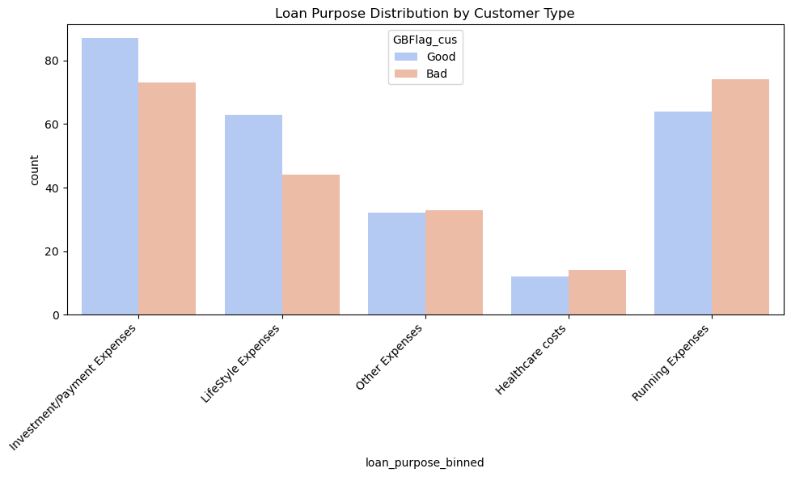

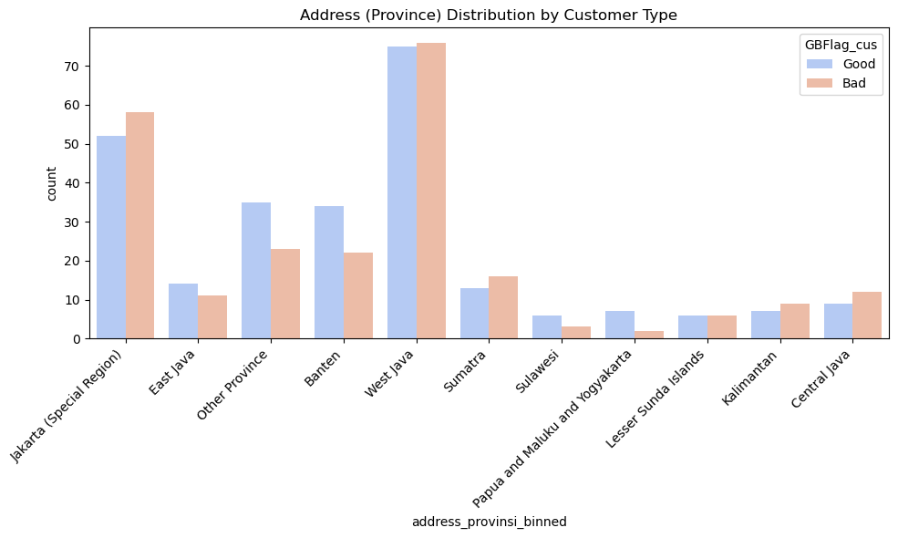

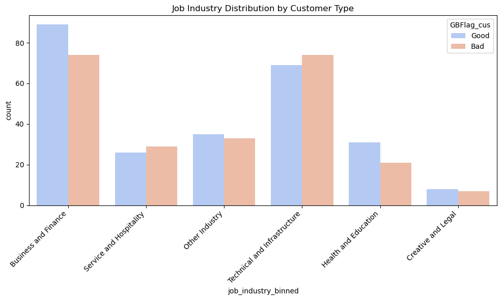

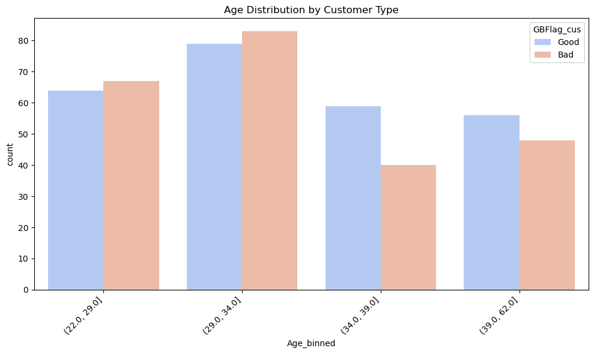

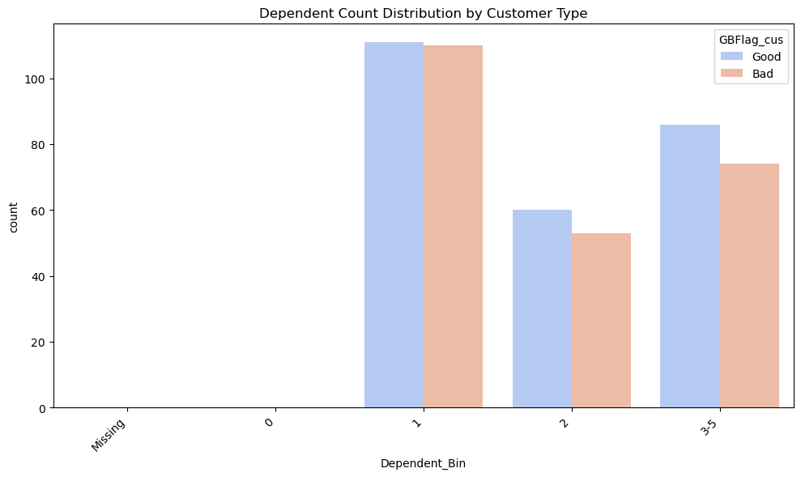

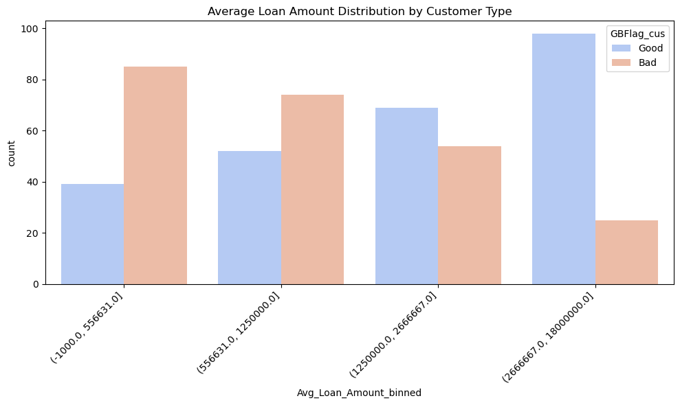

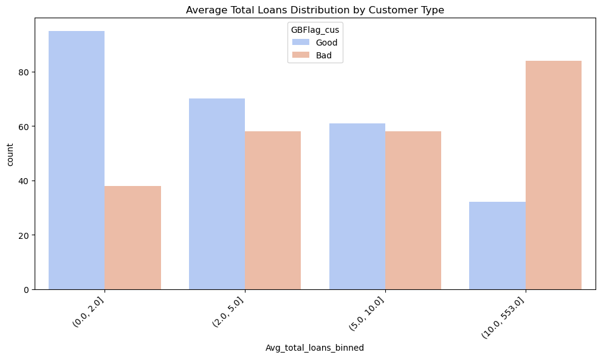

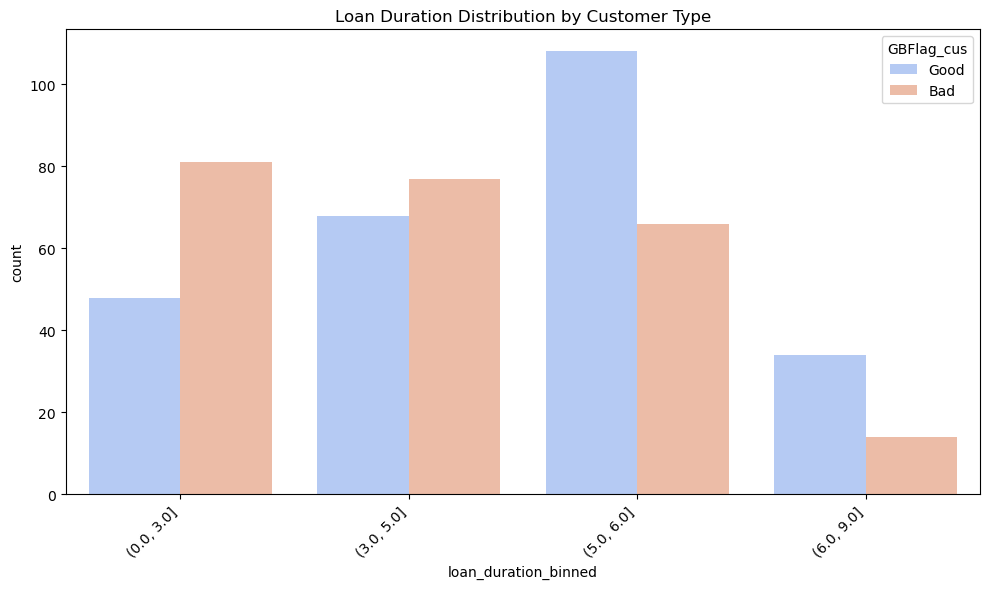

```python
# Visualize loan_purpose_binned distribution
plot_feature_distribution(df, 'loan_purpose_binned', 'Loan Purpose Distribution by Customer Type')

# Visualize address_provinsi_binned distribution
plot_feature_distribution(df, 'address_provinsi_binned', 'Address (Province) Distribution by Customer Type')

# Visualize job_industry_binned distribution
plot_feature_distribution(df, 'job_industry_binned', 'Job Industry Distribution by Customer Type')

# Visualize Age_binned distribution
plot_feature_distribution(df, 'Age_binned', 'Age Distribution by Customer Type')

# Visualize Dependent_Bin distribution
plot_feature_distribution(df, 'Dependent_Bin', 'Dependent Count Distribution by Customer Type')

# Visualize Avg_Loan_Amount_binned distribution
plot_feature_distribution(df, 'Avg_Loan_Amount_binned', 'Average Loan Amount Distribution by Customer Type')

# Visualize Avg_total_loans_binned distribution
plot_feature_distribution(df, 'Avg_total_loans_binned', 'Average Total Loans Distribution by Customer Type')

# Visualize loan_duration_binned distribution
plot_feature_distribution(df, 'loan_duration_binned', 'Loan Duration Distribution by Customer Type')
```

### 2. **Address (Province)**

- The distribution across provinces indicates that some regions may have a higher incidence of bad customers. If regions like "Jakarta (Special Region)" or "West Java" displayed a higher concentration of bad customers, it suggests geographical factors or economic conditions in those areas might influence default rates. This can inform geographic targeting and risk mitigation efforts.

### 3. **Job Industry**

- The job industry of borrowers also shows variation in the proportion of good and bad customers. Industries that appear more frequently among bad customers could indicate sectors with less stable income, influencing loan repayment capabilities. This insight can be used for employment verification and loan approval processes.

### 4. **Age**

- Age distribution suggests age groups from 22 to 34 might be more prone to being classified as bad customers. For example, if younger or older age bins show a higher ratio of bad customers, it might reflect different risk profiles based on life stage, financial stability, and credit experience.

### 6. **Average Loan Amount**

- The analysis of average loan amounts by customer type might reveal whether larger or smaller loans are more likely to be associated with bad customers. This could relate to the borrower's financial capability to manage debt.

### 7. **Average Total Loans**

- The number of loans taken by a customer and their risk classification suggests that customers with a higher number of loans might be at a higher risk of default. This insight is crucial for assessing a customer's debt burden and financial health.

### 8. **Loan Duration**

- Loan duration preferences between good and bad customers can indicate risk preferences or financial planning capabilities. Shorter or longer durations might be associated with different risk profiles, affecting default rates.

**Specific Insights on High-Risk Segments:**

- However, the business can use these insights to focus on loan purposes, industries, age groups, and other factors that show a higher proportion of bad customers for more detailed analysis. Identifying these patterns helps in refining underwriting criteria, setting targeted risk mitigation strategies, and potentially customizing product offerings to better manage and distribute risk across the portfolio.

By focusing on these insights, the business can more effectively identify and manage potential risks associated with loan approvals, contributing to a more robust and resilient financial strategy.

### Calculate WOE and IV

Weight of Evidence (WOE) and Information Value (IV) are key metrics in the development of credit scoring models, and their importance is especially pronounced in the realm of financial services, including banking and credit risk assessment. Here's why they are so crucial for feature engineering in this context:

##### Weight of Evidence (WOE)

1. **Transforms Variables**: WOE provides a method to transform categorical variables into a continuous measure, making it easier to include them in models that require numerical input, such as logistic regression.
2. **Handles Missing Values**: It offers a straightforward approach to deal with missing values, allowing for the incorporation of missingness as a separate category, if appropriate.
3. **Ensures Monotonic Relationship**: By using WOE, one can ensure a monotonic relationship between the independent variables and the log odds of the dependent variable, enhancing model performance and interpretability.
4. **Risk Differentiation**: It helps in differentiating the risk by assigning higher WOE values to categories that indicate higher risk, making it a natural fit for credit scoring models where risk assessment is key.

##### Information Value (IV)

1. **Feature Selection**: IV is an excellent tool for feature selection. It quantifies the predictive power of an independent variable in relation to the dependent variable. In credit scoring models, this helps in selecting the most relevant variables for predicting default risk.
2. **Assesses Predictive Power**: IV values range from 0 to infinity, with higher values indicating stronger predictive power. This allows modelers to rank variables by their importance in predicting the outcome.
3. **Reduces Overfitting**: By selecting only the variables with significant IV, you reduce the risk of overfitting your model with irrelevant or weak predictors.
4. **Simplicity and Efficiency**: IV calculation is straightforward and does not require building a model to assess the predictive power of a variable. This makes the feature selection process both efficient and effective.

##### Practical Implementation in Credit Scoring

In the context of credit scoring, WOE and IV are instrumental in developing robust models that accurately predict the likelihood of a borrower defaulting on a loan. These methods allow financial institutions to make informed decisions, manage risk effectively, and ensure regulatory compliance by providing clear, interpretable metrics for model development and variable selection.Overall, WOE and IV enhance the predictiveness and interpretability of credit scoring models, making them indispensable tools in the feature engineering phase of model development.

Feature we have,

Application Variables

1. loan_purpose_binned
2. address_provinsi_binned
3. marital_status
4. job_type
5. job_industry_binned

Numerical Variables

1. Age_binned
2. Dependent_Bin
3. Avg_Loan_Amount_binned
4. Avg_total_loans_binned
5. loan_duration_binned

```python
#  Splitting into Train and Test
Train = df.sample(frac=0.7, random_state=30)
Test = df[~(df['application_id'].isin(Train['application_id']))]
```

```python
print(Train.shape, Test.shape)
```

```
(347, 37) (149, 37)
```

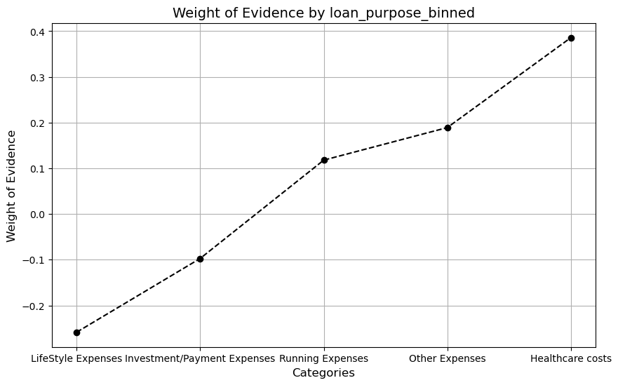

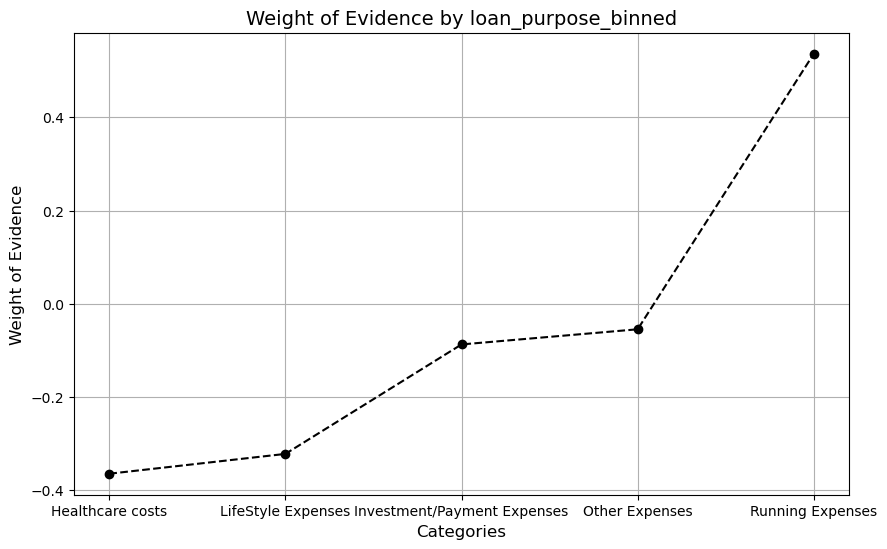

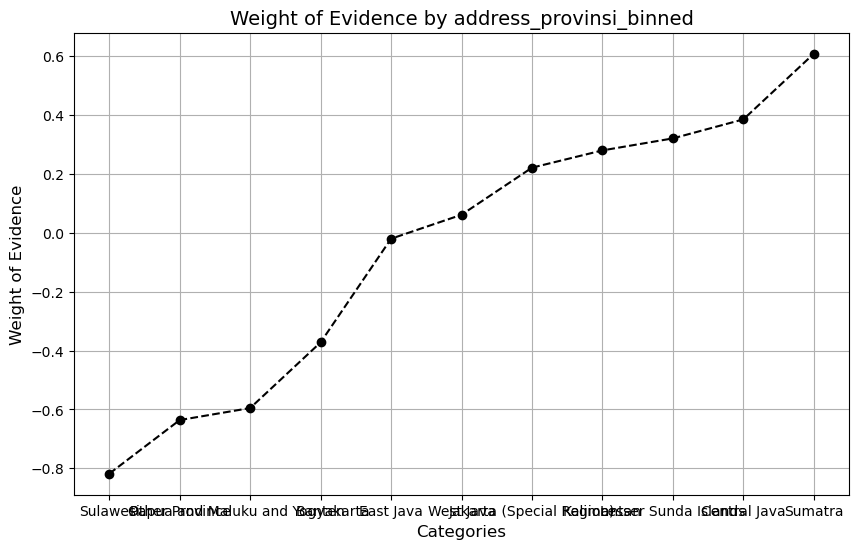

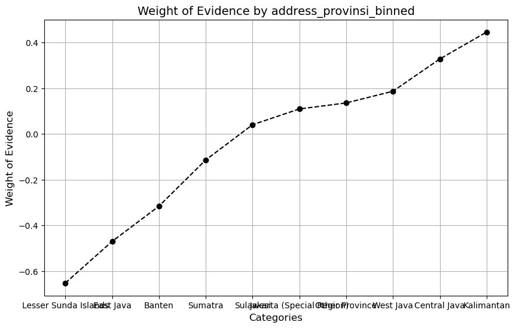

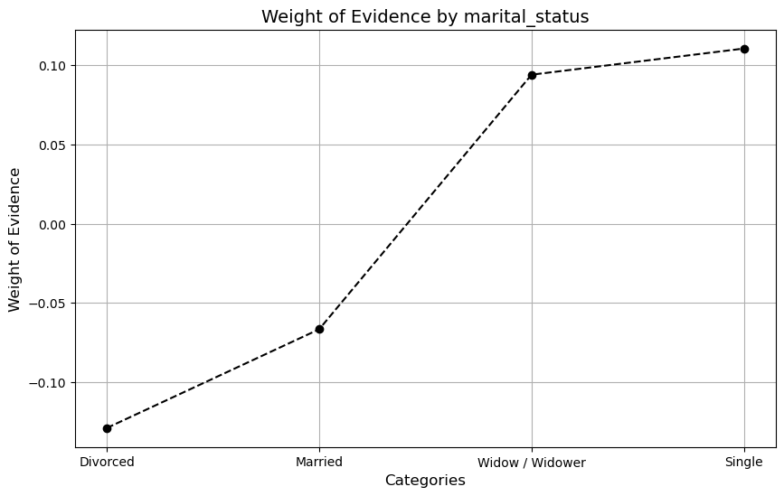

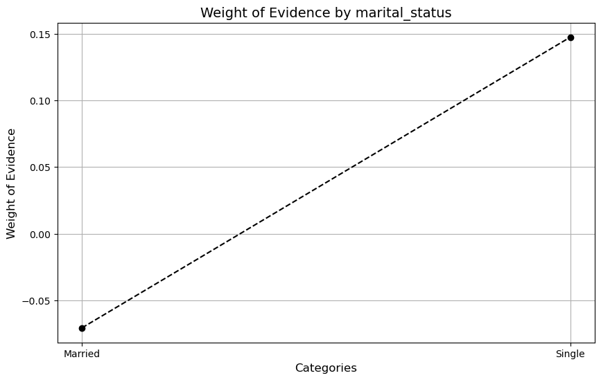

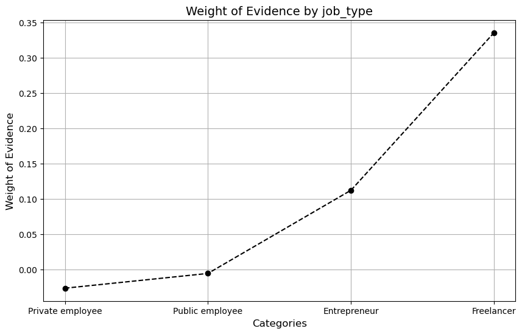

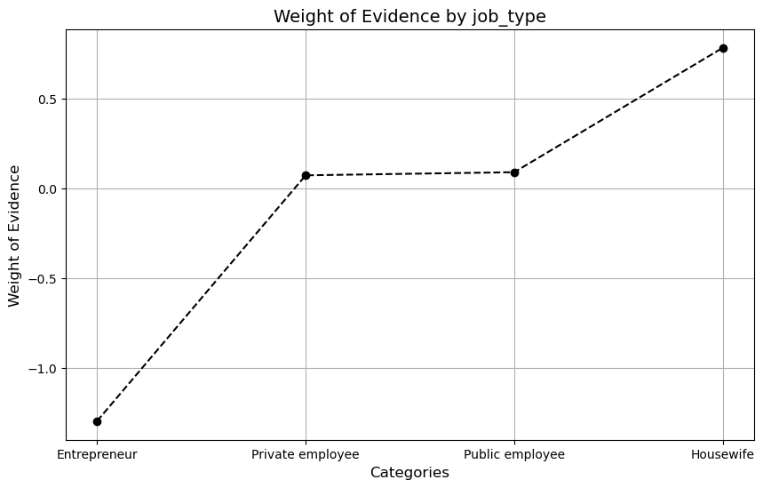

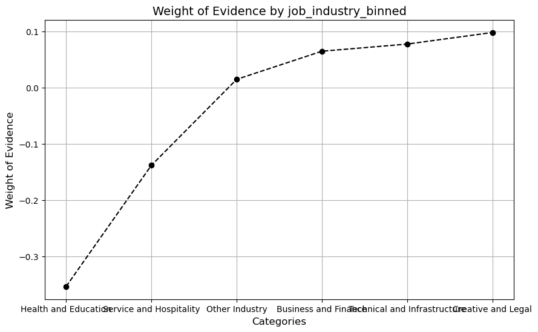

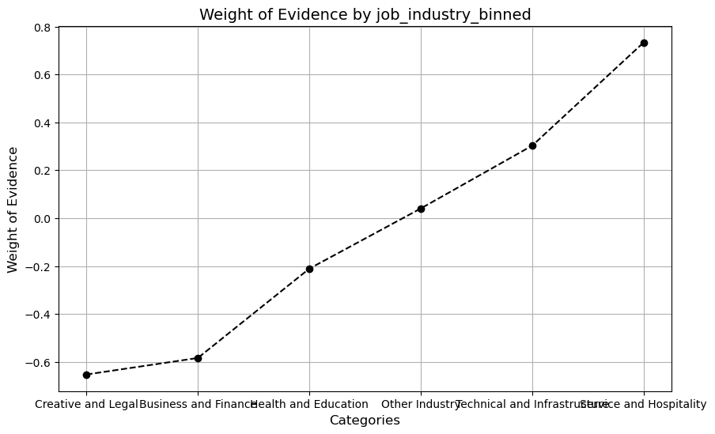

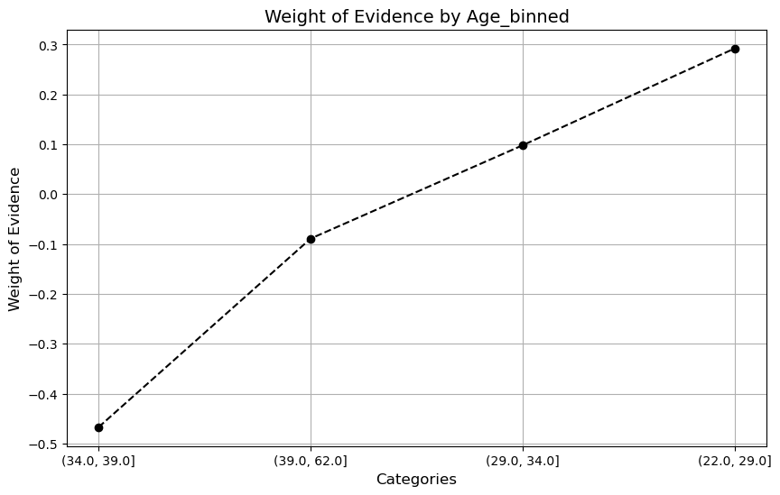

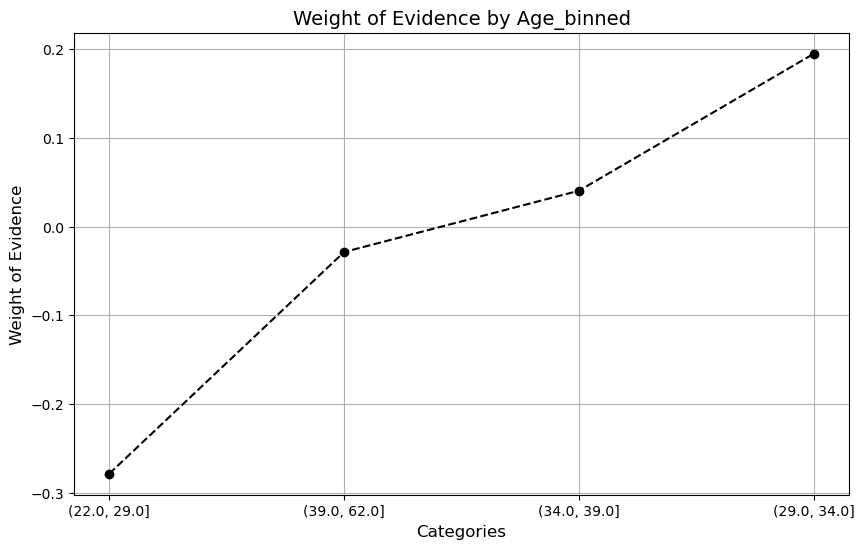

[8 more figures not shown]

```python
import pandas as pd

def calculate_woe_and_iv_for_all_features(df_train, df_test, features, target):
    woe_results = {}
    iv_summary = {'Feature': [], 'Train IV': [], 'Test IV': []}

    for feature in features:
        # Assuming woe_cat now returns a tuple of (DataFrame, IV value)
        woe_df_train, iv_train = woe_cat(df_train, feature, target)
        woe_df_test, iv_test = woe_cat(df_test, feature, target)
        plot_by_woe(woe_df_train, feature)
        plot_by_woe(woe_df_test, feature)


        # Combine Train and Test DataFrames with a spacer
        spacer_df = pd.DataFrame({(' ', ' ', f'Spacer_{i}'): [None] * len(woe_df_train) for i in range(1, 4)})
        woe_combined = pd.concat([woe_df_train, spacer_df, woe_df_test], axis=1)
        woe_results[feature] = woe_combined

        # Append IV values to the summary
        iv_summary['Feature'].append(feature)
        iv_summary['Train IV'].append(iv_train)
        iv_summary['Test IV'].append(iv_test)

    return woe_results, pd.DataFrame(iv_summary)

# Assuming df_train and df_test are your Train and Test datasets
features = ['loan_purpose_binned', 'address_provinsi_binned', 'marital_status', 'job_type', 'job_industry_binned',
            'Age_binned', 'Dependent_Bin', 'Avg_Loan_Amount_binned', 'Avg_total_loans_binned', 'loan_duration_binned']
target = 'GBFlag_cus'

# Calculate WoE for each feature for both Train and Test datasets and store the results
woe_results, iv_summary_df = calculate_woe_and_iv_for_all_features(Train, Test, features, target)

with pd.ExcelWriter('Characteristics_analysis_report.xlsx', engine="openpyxl") as writer:
    # Write each feature's WOE table to its sheet
    for variable_name, data in woe_results.items():
        data.to_excel(writer, sheet_name=variable_name, startrow=1)

    # Write the summary sheet
    iv_summary_df.to_excel(writer, sheet_name='Summary', index=False)
```

The Visuals proves we have monotonic relationship between Woe and Categories all over in test and train both that confirms accurate binning and GBOdds distribution is fine

```python
iv_summary_df
```

|  | Feature | Train IV | Test IV |
| --- | --- | --- | --- |
| 0 | loan_purpose_binned | 0.033590 | 0.104409 |
| 1 | address_provinsi_binned | 0.115458 | inf |
| 2 | marital_status | 0.007774 | inf |
| 3 | job_type | inf | 0.124068 |
| 4 | job_industry_binned | 0.018110 | 0.209600 |
| 5 | Age_binned | 0.069819 | 0.033219 |
| 6 | Dependent_Bin | 0.010465 | 0.001828 |
| 7 | Avg_Loan_Amount_binned | 0.696484 | 0.435320 |
| 8 | Avg_total_loans_binned | 0.452328 | 0.377763 |
| 9 | loan_duration_binned | 0.338292 | 0.110096 |

```python
# IV range is 0.02 to 0.5
# Choose variables that fit the criteria but for the sake of exc

# Filter the DataFrame for the condition where both Train IV and Test IV are in the specified range
filtered_iv_summary_df = iv_summary_df[(iv_summary_df['Train IV'] >= 0.02) &
                                       (iv_summary_df['Train IV'] <= 0.5) &
                                       (iv_summary_df['Test IV'] >= 0.02) &
                                       (iv_summary_df['Test IV'] <= 0.5)]
filtered_iv_summary_df
```

|  | Feature | Train IV | Test IV |
| --- | --- | --- | --- |
| 0 | loan_purpose_binned | 0.033590 | 0.104409 |
| 5 | Age_binned | 0.069819 | 0.033219 |
| 8 | Avg_total_loans_binned | 0.452328 | 0.377763 |
| 9 | loan_duration_binned | 0.338292 | 0.110096 |

#### Characteristic Analysis or CA Report

At this stage of the modeling, we compile CA report in which all the features alongiwth their respective WOE and IV for train and test present.

1. Information Value range: 0.02>x<0.5
2. Population Stablity Index: <0.2
3. Variance Inflation Factor: <5

Calculation of PSI and VIF is necessary before proceed for Modeling. The Process is to make sure the variables we will consider for modeling will be of strongest predictor.

In this exercise, we have only calculated Woe and IV to proceed.

##### PART 3 Scorecard Development

```python
selected_features = ['loan_purpose_binned', 'address_provinsi_binned', 'Age_binned', 'Avg_Loan_Amount_binned', 'Avg_total_loans_binned', 'loan_duration_binned']
# selected_features = ['loan_purpose_binned', 'Age_binned', 'Avg_total_loans_binned', 'loan_duration_binned']
```

```python
woe_iv_df = woe_iv(Train, selected_features, target)
woe_iv_df.head()
```

|  | Variables | Categories | WOE | IV |
| --- | --- | --- | --- | --- |
| 0 | loan_purpose_binned | LifeStyle Expenses | -0.258614 | 0.03359 |
| 1 | loan_purpose_binned | Investment/Payment Expenses | -0.097248 | 0.03359 |
| 2 | loan_purpose_binned | Running Expenses | 0.117864 | 0.03359 |
| 3 | loan_purpose_binned | Other Expenses | 0.189033 | 0.03359 |
| 4 | loan_purpose_binned | Healthcare costs | 0.385743 | 0.03359 |

```python
### Get features and target variables
X_train = Train.drop(['GBFlag_cus'], axis=1)
y_train = Train['GBFlag_cus']
X_test = Test.drop(['GBFlag_cus'], axis=1)
y_test = Test['GBFlag_cus']

X_train = X_train[selected_features]
X_test = X_test[selected_features]


print('X_train: ', X_train.shape)
print('X_test: ', X_test.shape)
print('y_train: ', y_train.shape)
print('y_test: ', y_test.shape)
```

```
X_train:  (347, 6)
X_test:  (149, 6)
y_train:  (347,)
y_test:  (149,)
```

```python
X_train.isnull().sum()
```

```
loan_purpose_binned        0
address_provinsi_binned    0
Age_binned                 0
Avg_Loan_Amount_binned     0
Avg_total_loans_binned     0
loan_duration_binned       0
dtype: int64
```

```python
## Replace categories with their respective WoEs
X_train = replace_with_woe(X_train, woe_iv_df)
X_test = replace_with_woe(X_test, woe_iv_df)

### Replcae inf and -inf with 0 before passing thru model
X_train.replace([np.inf, -np.inf], 0, inplace=True)
X_test.replace([np.inf, -np.inf], 0, inplace=True)
```

```python
# Replace target label with appropriate code. Good-0, Bad-1
y_train = y_train.replace({'Good': 0, 'Bad': 1})
y_test = y_test.replace({'Good': 0, 'Bad': 1})

X_train = X_train.apply(pd.to_numeric, errors='ignore')
X_test = X_test.apply(pd.to_numeric, errors='ignore')
```

```python
X_test.head()
```

|  | loan_purpose_binned | address_provinsi_binned | Age_binned | Avg_Loan_Amount_binned | Avg_total_loans_binned | loan_duration_binned |
| --- | --- | --- | --- | --- | --- | --- |
| 9 | -0.258614 | 0.221675 | 0.098061 | -1.247959 | 0.098061 | -0.474458 |
| 11 | 0.117864 | -0.371942 | 0.098061 | -1.247959 | 0.098061 | -0.923590 |
| 14 | 0.117864 | 0.221675 | -0.089150 | -0.359772 | -0.246779 | 0.098061 |
| 15 | -0.258614 | 0.061694 | -0.089150 | 1.030881 | 1.101363 | 0.098061 |
| 16 | -0.097248 | 0.608887 | -0.467253 | -1.247959 | -0.803841 | -0.474458 |

We are going to test various Models and based uoon the Gini and AucRoc score we are gonna check which model is best to use

```python
from sklearn.model_selection import StratifiedKFold, cross_validate
from sklearn.metrics import make_scorer, precision_score, recall_score, f1_score, roc_auc_score, roc_curve, auc, confusion_matrix
from sklearn.ensemble import RandomForestClassifier
from sklearn.tree import DecisionTreeClassifier
from sklearn.linear_model import LogisticRegression
from catboost import CatBoostClassifier
from xgboost import XGBClassifier
from lightgbm import LGBMClassifier
import numpy as np
import pandas as pd

# Define custom scoring function for Gini coefficient
def gini_score(y_true, y_pred):
    fpr, tpr, _ = roc_curve(y_true, y_pred)
    roc_auc = auc(fpr, tpr)
    gini_coefficient = 2 * roc_auc - 1
    return gini_coefficient

# Create Stratified K-fold cross-validation
cv = StratifiedKFold(n_splits=5, random_state=1, shuffle=True)

# Define scoring metrics
scoring = {
    'f1': make_scorer(f1_score),
    'precision': make_scorer(precision_score),
    'recall': make_scorer(recall_score),
    'auc-roc': make_scorer(roc_auc_score),
    'gini': make_scorer(gini_score)
}

# Initialize models
models = {
    'Random Forest': RandomForestClassifier(),
    'Decision Tree': DecisionTreeClassifier(),
    'Logistic Regression': LogisticRegression(),
    'CatBoost': CatBoostClassifier(),
    'XGBoost': XGBClassifier(),
    'LightGBM': LGBMClassifier()
}

# Initialize results dictionary
results = {'Model': [], 'F1-score': [], 'Precision': [], 'Recall': [], 'AUC-ROC': [], 'Gini': []}

# Evaluate each model
for model_name, model in models.items():
    scores = cross_validate(model, X_train, y_train, scoring=scoring, cv=cv)
    results['Model'].append(model_name)
    results['F1-score'].append(np.mean(scores['test_f1']))
    results['Precision'].append(np.mean(scores['test_precision']))
    results['Recall'].append(np.mean(scores['test_recall']))
    results['AUC-ROC'].append(np.mean(scores['test_auc-roc']))
    results['Gini'].append(np.mean(scores['test_gini']))

# Create results DataFrame
results_df = pd.DataFrame(results)

# Display results
results_df
```

[output not shown]

[output cut: 4950 more lines]

[output not shown]

|  | Model | F1-score | Precision | Recall | AUC-ROC | Gini |
| --- | --- | --- | --- | --- | --- | --- |
| 0 | Random Forest | 0.557307 | 0.569003 | 0.551515 | 0.583190 | 0.166380 |
| 1 | Decision Tree | 0.529856 | 0.533983 | 0.527273 | 0.551699 | 0.103399 |
| 2 | Logistic Regression | 0.649519 | 0.656621 | 0.648485 | 0.670414 | 0.340827 |
| 3 | CatBoost | 0.583243 | 0.602890 | 0.575758 | 0.614831 | 0.229661 |
| 4 | XGBoost | 0.549185 | 0.550334 | 0.551515 | 0.572529 | 0.145059 |
| 5 | LightGBM | 0.592568 | 0.611637 | 0.581818 | 0.620639 | 0.241278 |

Seemslike, Logistic Regession have best Gini of 34% with AUC-ROC 67%

```python
X_train_sm = sm.add_constant(X_train)
X_test_sm = sm.add_constant(X_test)

## Fit the model
model = sm.Logit(np.array(y_train), X_train_sm)
result = model.fit()

## Get Model Predictions
train_pred = result.predict(X_train_sm)
test_pred = result.predict(X_test_sm)

Test_Gini, Train_Gini = compute_gini(y_test, y_train, test_pred, train_pred)
display(result.summary2())

print('Model AIC:', round(result.aic, 3))
print('Model Train Gini:', round(Train_Gini, 3))
print('Model Test Gini:', round(Test_Gini, 3))

print("Diff: ", (Train_Gini - Test_Gini)/Train_Gini)
```

```
Optimization terminated successfully.
         Current function value: 0.579070
         Iterations 5
```

| Model: | Logit | Method: | MLE |
| --- | --- | --- | --- |
| Dependent Variable: | y | Pseudo R-squared: | 0.163 |
| Date: | 2024-03-10 12:48 | AIC: | 415.8746 |
| No. Observations: | 347 | BIC: | 442.8199 |
| Df Model: | 6 | Log-Likelihood: | -200.94 |
| Df Residuals: | 340 | LL-Null: | -240.11 |
| Converged: | 1.0000 | LLR p-value: | 7.8791e-15 |
| No. Iterations: | 5.0000 | Scale: | 1.0000 |

|  | Coef. | Std.Err. | z | P>\|z\| | [0.025 | 0.975] |
| --- | --- | --- | --- | --- | --- | --- |
| const | -0.0982 | 0.1210 | -0.8111 | 0.4173 | -0.3353 | 0.1390 |
| loan_purpose_binned | 0.9917 | 0.6682 | 1.4841 | 0.1378 | -0.3180 | 2.3013 |
| address_provinsi_binned | 0.9438 | 0.3639 | 2.5935 | 0.0095 | 0.2305 | 1.6570 |
| Age_binned | 0.8594 | 0.4627 | 1.8573 | 0.0633 | -0.0475 | 1.7664 |
| Avg_Loan_Amount_binned | 0.7550 | 0.1934 | 3.9030 | 0.0001 | 0.3759 | 1.1341 |
| Avg_total_loans_binned | 0.5677 | 0.2035 | 2.7901 | 0.0053 | 0.1689 | 0.9664 |
| loan_duration_binned | 0.0205 | 0.2640 | 0.0775 | 0.9382 | -0.4969 | 0.5378 |

```
Model AIC: 415.875
Model Train Gini: 0.523
Model Test Gini: 0.355
Diff:  0.32193977925377776
```

Conventionally, the Difference between Train and Test Gini should not be more 5%. For the sake of exercise, we are letting go this issue otherwise here we need to go back and check our training sample and its GBOdds Distribution Again.

```python
ds = df[['application_id', 'GBFlag_cus', 'loan_purpose_binned', 'address_provinsi_binned',
       'job_industry_binned', 'Age_binned', 'Dependent_Bin',
       'Avg_Loan_Amount_binned', 'Avg_total_loans_binned',
       'loan_duration_binned']]
```

```python
ds.head()
```

|  | application_id | GBFlag_cus | loan_purpose_binned | address_provinsi_binned | job_industry_binned | Age_binned | Dependent_Bin | Avg_Loan_Amount_binned | Avg_total_loans_binned | loan_duration_binned |
| --- | --- | --- | --- | --- | --- | --- | --- | --- | --- | --- |
| 0 | 2004025560801 | Good | Investment/Payment Expenses | Jakarta (Special Region) | Business and Finance | (34.0, 39.0] | 2 | (1250000.0, 2666667.0] | (2.0, 5.0] | (5.0, 6.0] |
| 1 | 2004025574618 | Good | LifeStyle Expenses | Jakarta (Special Region) | Service and Hospitality | (29.0, 34.0] | 1 | (1250000.0, 2666667.0] | (2.0, 5.0] | (5.0, 6.0] |
| 2 | 2004025576523 | Good | Other Expenses | East Java | Other Industry | (34.0, 39.0] | 3-5 | (1250000.0, 2666667.0] | (5.0, 10.0] | (3.0, 5.0] |
| 3 | 2004025579060 | Good | Healthcare costs | Jakarta (Special Region) | Service and Hospitality | (34.0, 39.0] | 2 | (556631.0, 1250000.0] | (5.0, 10.0] | (3.0, 5.0] |
| 4 | 2004025589544 | Bad | Investment/Payment Expenses | Other Province | Technical and Infrastructure | (29.0, 34.0] | 1 | (556631.0, 1250000.0] | (2.0, 5.0] | (3.0, 5.0] |

```
AUC-ROC: 0.6772710886806057
Gini: 0.3545421773612114
Confusion Matrix:
[[53 23]
 [33 40]]
Accuracy: 0.6241610738255033
KS: 0.3444484498918529
```

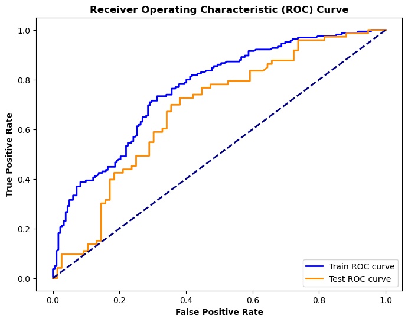

```python
import numpy as np
import matplotlib.pyplot as plt
from sklearn.metrics import roc_curve, auc, roc_auc_score
from sklearn.metrics import confusion_matrix, accuracy_score

# Calculate AUC-ROC
auc_roc_train = roc_auc_score(y_train, train_pred)
auc_roc_test = roc_auc_score(y_test, test_pred)

# Plot ROC curves for both training and testing sets
fpr_train, tpr_train, _ = roc_curve(y_train, train_pred)
fpr_test, tpr_test, _ = roc_curve(y_test, test_pred)

# Calculate Gini
gini = 2 * auc_roc_test - 1

# Convert predicted probabilities to binary predictions
y_pred = np.round(test_pred)

# Confusion Matrix
conf_matrix = confusion_matrix(y_test, y_pred)

# Accuracy
accuracy = accuracy_score(y_test, y_pred)

# Calculate KS (Kolmogorov-Smirnov) statistic
ks = max(tpr_test - fpr_test)

# Display the results
print(f"AUC-ROC: {auc_roc_test}")
print(f"Gini: {gini}")
print("Confusion Matrix:")
print(conf_matrix)
print(f"Accuracy: {accuracy}")
print(f"KS: {ks}")

plt.figure(figsize=(8, 6))
plt.plot(fpr_train, tpr_train, color='blue', lw=2, label='Train ROC curve' )
plt.plot(fpr_test, tpr_test, color='darkorange', lw=2, label='Test ROC curve')
plt.plot([0, 1], [0, 1], color='navy', lw=2, linestyle='--')
plt.xlabel('False Positive Rate', fontweight='bold')
plt.ylabel('True Positive Rate', fontweight='bold')
plt.title('Receiver Operating Characteristic (ROC) Curve', fontweight='bold')
plt.legend(loc='lower right')
plt.show()
```

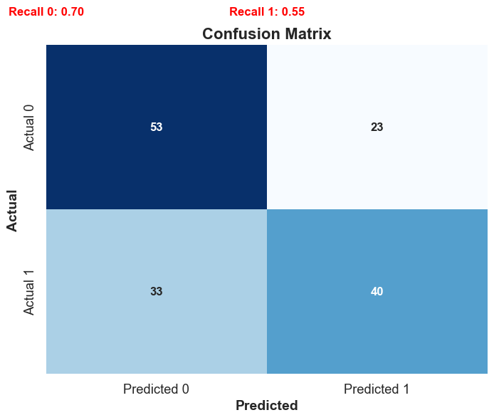

```python
import seaborn as sns
# Create confusion matrix
# Create confusion matrix
# Create confusion matrix
conf_matrix = confusion_matrix(y_test, y_pred)

# Calculate recall rates
recall_0 = conf_matrix[0, 0] / (conf_matrix[0, 0] + conf_matrix[0, 1])
recall_1 = conf_matrix[1, 1] / (conf_matrix[1, 0] + conf_matrix[1, 1])

# Set font size for heatmap
sns.set(font_scale=1.2)  # Adjust the value as needed

# Plot the confusion matrix using a heatmap
plt.figure(figsize=(8, 6))
ax = sns.heatmap(conf_matrix, annot=True, fmt='d', cmap='Blues', cbar=False,
                 xticklabels=['Predicted 0', 'Predicted 1'],
                 yticklabels=['Actual 0', 'Actual 1'],
                 annot_kws={"size": 12, "weight": "bold"})  # Adjust size and weight as needed

# Add recall rates as text annotations
plt.text(0, -0.2, f'Recall 0: {recall_0:.2f}', ha='center', va='center', color='red', fontweight='bold', fontsize=12)
plt.text(1, -0.2, f'Recall 1: {recall_1:.2f}', ha='center', va='center', color='red', fontweight='bold', fontsize=12)

plt.xlabel('Predicted', fontsize=14, fontweight='bold')
plt.ylabel('Actual', fontsize=14, fontweight='bold')
plt.title('Confusion Matrix', fontsize=16, fontweight='bold')
plt.show()
```

#### Which metrics do you use? and why?

In Credit Scoring , we use Gini Coefficent as a Bench mark metric to check how is model performing on test. Any Gini above 25% is good to have in corporate environment. With a Real time Data, Gini above 35% basically means your model is discrimating Good and Bad Customers decently.

Later on, Quaterly Monitoring of Scorecard Involves Gini and AUC Roc Shift. If Gini goes below 25% means model needs redevelopment.

#### Explain why your model can be considered as good enough.

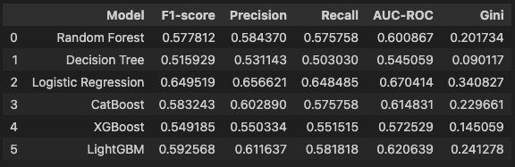

A Model consider to be good enough if the discrimation of GOOD and BAD customer is decent enough. Gini Coefficeint gives us the benchmark to check that and image shows logistic regression is the best one to use among the rest.

#### How can the business use the model?

Business can use the Model Predictions i.e. Probablity of Default to Accept or Reject Customer at the time of Application but setting up a scorecard threhold. For Business we develop a Cutoff Strategy Report to check Profit/Loss and Cummulative Bad Rates and different Scorecard Scales.

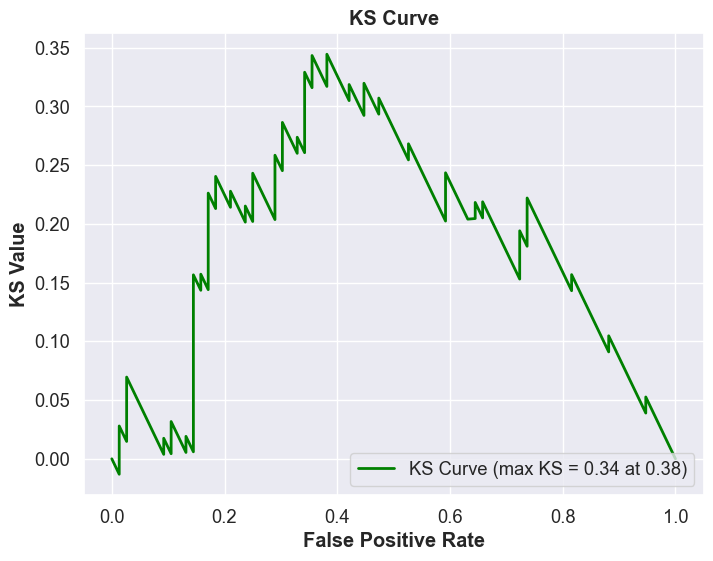

```python
# Calculate KS (Kolmogorov-Smirnov) statistic for each point on the ROC curve
ks_values = tpr_test - fpr_test

# Find the index corresponding to the maximum KS value
max_ks_index = np.argmax(ks_values)

# Plot the KS curve
plt.figure(figsize=(8, 6))
plt.plot(fpr_test, ks_values, color='green', lw=2, label='KS Curve (max KS = {:.2f} at {:.2f})'.format(ks_values[max_ks_index], fpr_test[max_ks_index]))
plt.xlabel('False Positive Rate', fontweight='bold')
plt.ylabel('KS Value', fontweight='bold')
plt.title('KS Curve', fontweight='bold')
plt.legend(loc='lower right')
plt.show()
```

##### PART 4 Cut off strategy

```python
X  = X_train[selected_features]
y = y_train
```

```python
print(Train.shape, X_train.shape)
```

```
(347, 37) (347, 6)
```

```python
X_sm= sm.add_constant(X)
X_pred = result.predict(X_sm)

train_pred = result.predict(X_train_sm)
Train['PD'] = np.round(X_pred*1000)
Train.head()
```

|  | application_id | customer_id_str | dob | Age | loan_purpose | loan_purpose_desc | address_provinsi | marital_status | dependent | job_type | ... | GBFlag_cus | loan_purpose_binned | address_provinsi_binned | job_industry_binned | Age_binned | Dependent_Bin | Avg_Loan_Amount_binned | Avg_total_loans_binned | loan_duration_binned | PD |
| --- | --- | --- | --- | --- | --- | --- | --- | --- | --- | --- | --- | --- | --- | --- | --- | --- | --- | --- | --- | --- | --- |
| 21 | 2004025668859 | 2.003022e+12 | 1990-07-20 | 33.0 | Healthcare costs | persiapan persalinan untuk tes rapid atau sweb... | dki jakarta | Married | 0.0 | Private employee | ... | Bad | Healthcare costs | Jakarta (Special Region) | Business and Finance | (29.0, 34.0] | 1 | (1250000.0, 2666667.0] | (5.0, 10.0] | (3.0, 5.0] | 590.0 |
| 237 | 2004026541955 | 2.003024e+12 | 1983-04-04 | 40.0 | Miscellaneous | kebutuhan sehari..hari untuk memenuhi kebutuha... | jawa barat | Married | 3.0 | Private employee | ... | Bad | Other Expenses | West Java | Technical and Infrastructure | (39.0, 62.0] | 3-5 | (-1000.0, 556631.0] | (0.0, 2.0] | (3.0, 5.0] | 597.0 |
| 287 | 2004026709710 | 2.003021e+12 | 1989-07-20 | 34.0 | Healthcare costs | untuk biaya persiapan kesehatan terutama di te... | kalimantan timur | Married | 2.0 | Entrepreneur | ... | Good | Healthcare costs | Kalimantan | Health and Education | (29.0, 34.0] | 3-5 | (2666667.0, 18000000.0] | (2.0, 5.0] | (5.0, 6.0] | 387.0 |
| 371 | 2004027199079 | 2.003024e+12 | 1972-03-14 | 51.0 | Home renovation | untuk renovasi rumah,pembelian matrial dan bay... | banten | Married | 3.0 | Private employee | ... | Bad | LifeStyle Expenses | Banten | Technical and Infrastructure | (39.0, 62.0] | 3-5 | (-1000.0, 556631.0] | (10.0, 553.0] | (0.0, 3.0] | 654.0 |
| 22 | 2004025670424 | 2.003023e+12 | 1997-07-05 | 26.0 | Educational expenses | untuk biaya pendidikan. mohon dibantu pengajua... | dki jakarta | Married | 0.0 | Private employee | ... | Bad | Running Expenses | Jakarta (Special Region) | Business and Finance | (22.0, 29.0] | 1 | (556631.0, 1250000.0] | (5.0, 10.0] | (5.0, 6.0] | 712.0 |

5 rows × 38 columns

```python
Train.columns
```

```
Index(['application_id', 'customer_id_str', 'dob', 'Age', 'loan_purpose',
       'loan_purpose_desc', 'address_provinsi', 'marital_status', 'dependent',
       'job_type', 'job_industry', 'loan_id', 'Disb_Month', 'loan_amount',
       'recovered_amount', 'loan_duration', 'installment_amount', 'loan_num',
       'total_loans', 'dpd_calculated_max', 'GBFlag', 'Min_Loan_Amount',
       'Max_Loan_Amount', 'Avg_Loan_Amount', 'Defaulted_Loans',
       'Total_Amount_Disbursed', 'Total_Amount_Recovered', 'Recovery_Rate',
       'GBFlag_cus', 'loan_purpose_binned', 'address_provinsi_binned',
       'job_industry_binned', 'Age_binned', 'Dependent_Bin',
       'Avg_Loan_Amount_binned', 'Avg_total_loans_binned',
       'loan_duration_binned', 'PD'],
      dtype='object')
```

```python
Train['Variable Cost'] = Train['Avg_Loan_Amount'] * 0.136
```

```python
Train['Profit/Loss'] = Train['recovered_amount'] - (Train['Avg_Loan_Amount'] + Train['Variable Cost'])
```

```python
model_cutoff = Train[['application_id','loan_amount','recovered_amount','Avg_Loan_Amount','Variable Cost','Profit/Loss', 'loan_purpose_binned', 'address_provinsi_binned',
       'job_industry_binned', 'Age_binned', 'Dependent_Bin',
       'Avg_Loan_Amount_binned', 'Avg_total_loans_binned',
       'loan_duration_binned','GBFlag_cus','PD']]
model_cutoff.shape
```

```
(347, 16)
```

```python
model_cutoff['PD_Binned'] = pd.qcut(model_cutoff['PD'], q=16, precision=0)
model_cutoff['GBFlag_cus'] = model_cutoff['GBFlag_cus'].replace({1: 'Bad', 0:'Good'})
model_cutoff.head(5)
```

|  | application_id | loan_amount | recovered_amount | Avg_Loan_Amount | Variable Cost | Profit/Loss | loan_purpose_binned | address_provinsi_binned | job_industry_binned | Age_binned | Dependent_Bin | Avg_Loan_Amount_binned | Avg_total_loans_binned | loan_duration_binned | GBFlag_cus | PD | PD_Binned |
| --- | --- | --- | --- | --- | --- | --- | --- | --- | --- | --- | --- | --- | --- | --- | --- | --- | --- |
| 21 | 2004025668859 | 3000000.0 | 4200000.0 | 1.600000e+06 | 217600.000000 | 2.382400e+06 | Healthcare costs | Jakarta (Special Region) | Business and Finance | (29.0, 34.0] | 1 | (1250000.0, 2666667.0] | (5.0, 10.0] | (3.0, 5.0] | Bad | 590.0 | (520.0, 590.0] |
| 237 | 2004026541955 | 500000.0 | 0.0 | 5.000000e+05 | 68000.000000 | -5.680000e+05 | Other Expenses | West Java | Technical and Infrastructure | (39.0, 62.0] | 3-5 | (-1000.0, 556631.0] | (0.0, 2.0] | (3.0, 5.0] | Bad | 597.0 | (590.0, 632.0] |
| 287 | 2004026709710 | 6000000.0 | 5708000.0 | 5.333333e+06 | 725333.333333 | -3.506667e+05 | Healthcare costs | Kalimantan | Health and Education | (29.0, 34.0] | 3-5 | (2666667.0, 18000000.0] | (2.0, 5.0] | (5.0, 6.0] | Good | 387.0 | (384.0, 424.0] |
| 371 | 2004027199079 | 108065.0 | 120000.0 | 1.201557e+05 | 16341.172480 | -1.649685e+04 | LifeStyle Expenses | Banten | Technical and Infrastructure | (39.0, 62.0] | 3-5 | (-1000.0, 556631.0] | (10.0, 553.0] | (0.0, 3.0] | Bad | 654.0 | (632.0, 664.0] |
| 22 | 2004025670424 | 2500000.0 | 3696000.0 | 1.226770e+06 | 166840.686000 | 2.302390e+06 | Running Expenses | Jakarta (Special Region) | Business and Finance | (22.0, 29.0] | 1 | (556631.0, 1250000.0] | (5.0, 10.0] | (5.0, 6.0] | Bad | 712.0 | (664.0, 717.0] |

#### If the business would like to achieve 2% cumulative default rate, which loans should we accept?**

The analysis indicates that to achieve a 2% cumulative default rate, loans with a Probability of Default (PD) score of 96 or lower should be considered for acceptance. This threshold is highlighted in the plot, where the cumulative default rate line crosses the 2% marker, and is visualized by the green vertical line.

This threshold helps in making precise, data-driven decisions on which loans to approve, targeting a conservative default rate that minimizes risk while potentially excluding higher-risk loans.

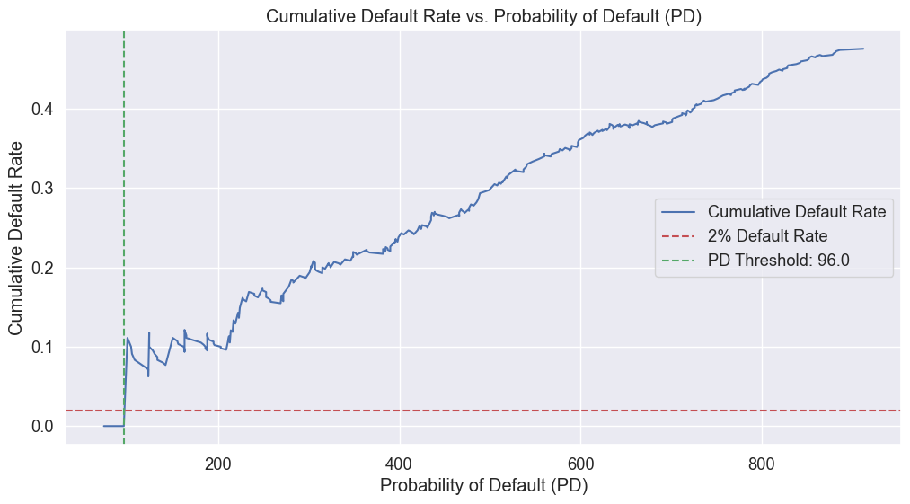

```python
# Create a flag indicating default (1 for Bad customers, 0 for Good customers)
model_cutoff['default_flag'] = (model_cutoff['GBFlag_cus'] == 'Bad').astype(int)

# Sort data by PD score
data_sorted = model_cutoff.sort_values('PD')

# Calculate cumulative default rate
data_sorted['cumulative_defaults'] = data_sorted['default_flag'].cumsum()
data_sorted['cumulative_total'] = range(1, len(data_sorted) + 1)
data_sorted['cumulative_default_rate'] = data_sorted['cumulative_defaults'] / data_sorted['cumulative_total']

# Identify the maximum PD score for a 2% cumulative default rate
max_pd_for_2_percent_default = data_sorted[data_sorted['cumulative_default_rate'] <= 0.02]['PD'].max()

plt.figure(figsize=(12, 6))
plt.plot(data_sorted['PD'], data_sorted['cumulative_default_rate'], label='Cumulative Default Rate')
plt.axhline(y=0.02, color='r', linestyle='--', label='2% Default Rate')
plt.axvline(x=max_pd_for_2_percent_default, color='g', linestyle='--', label=f'PD Threshold: {max_pd_for_2_percent_default}')

plt.title('Cumulative Default Rate vs. Probability of Default (PD)')
plt.xlabel('Probability of Default (PD)')
plt.ylabel('Cumulative Default Rate')
plt.legend()

plt.show()
```

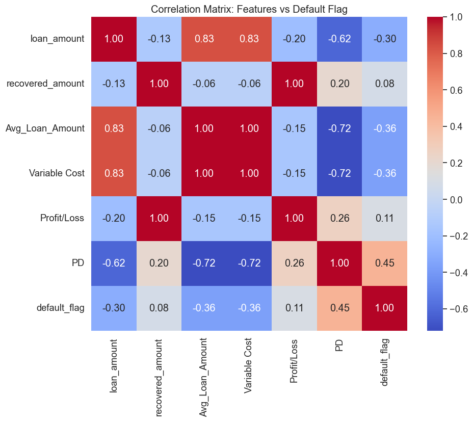

```python
# Calculate correlation matrix focusing on default_flag
correlation_matrix = data_sorted[['loan_amount', 'recovered_amount', 'Avg_Loan_Amount', 'Variable Cost', 'Profit/Loss', 'PD', 'default_flag']].corr()

# Visualize the correlation matrix
plt.figure(figsize=(10, 8))
sns.heatmap(correlation_matrix, annot=True, cmap='coolwarm', fmt=".2f")
plt.title('Correlation Matrix: Features vs Default Flag')
plt.show()
```

#### What are the characteristics of a defaulter, and how important are they?

Based on the correlation analysis and the distribution of PD scores:

Most of the Loans taken by customers from Jawa Barat Province, Married, Age 30 with No Dependents and have taken 2 loans atleast.

Financial metrics like loan amount and recovered amount have some relationship with default risk but are not as predictive as the PD score. This suggests that while the size and recovery of a loan matter, the customer's probability of default score is a more direct measure of risk.

For businesses looking to minimize default risk, focusing on PD scores as a primary criterion for loan approval is a data-driven strategy. However, it's also essential to consider the full financial context, including loan amounts, recovery efforts, and the cost of issuing loans, as these factors collectively influence the overall risk and profitability of loan portfolios.

To further refine risk management strategies, businesses could explore additional variables (if available) or develop more sophisticated models that incorporate a broader range of predictive factors, including customer demographics, credit history, and economic conditions

```python
model_cutoff.to_excel('model results.xlsx')
```

#### Profit/Loss Analysis

Lets look at deeply where the profit with respect to Default rates. it will help business and product to identify where to apply cap to maintain disbursment and mitigate risk at the same time

```python
import pandas as pd

def cut_off_strat(data):
    temp_dict = {}

    df = pd.crosstab(data['PD_Binned'], data['GBFlag_cus'])
    df['Total'] = df.sum(axis=1)
    df['Bad.Rates'] = df['Bad']/df['Total']
    df['Cumulative.Default.Rate'] = df['Bad.Rates'].cumsum()  # Calculate cumulative default rate
    df['GBOdds'] = df['Good']/df['Bad']

    for PD in df.index:
        Disbs = data[data['PD_Binned']==PD]['loan_amount'].sum().astype(int)
        Disbs_Good = data[(data['PD_Binned']==PD) & (data['GBFlag_cus']=='Good')]['loan_amount'].sum().astype(int)
        Disbs_Bad = data[(data['PD_Binned']==PD) & (data['GBFlag_cus']=='Bad')]['loan_amount'].sum().astype(int)
        Repayments = data[data['PD_Binned']==PD]['recovered_amount'].sum().astype(int)
        Repayments_Good = data[(data['PD_Binned']==PD) & (data['GBFlag_cus']=='Good')]['recovered_amount'].sum().astype(int)
        Repayments_Bad = data[(data['PD_Binned']==PD) & (data['GBFlag_cus']=='Bad')]['recovered_amount'].sum().astype(int)
        Variable_Cost = data[data['PD_Binned']==PD]['Variable Cost'].sum().astype(int)
        Profit = data[data['PD_Binned']==PD]['Profit/Loss'].sum().astype(int)
        Mean_Profit = data[data['PD_Binned']==PD]['Profit/Loss'].mean()

        temp_dict.setdefault('Disbursements',[]).append(Disbs)
        temp_dict.setdefault('Disb.Good',[]).append(Disbs_Good)
        temp_dict.setdefault('Disb.Bad',[]).append(Disbs_Bad)
        temp_dict.setdefault('Repayments',[]).append(Repayments)
        temp_dict.setdefault('Repay.Good',[]).append(Repayments_Good)
        temp_dict.setdefault('Repay.Bad',[]).append(Repayments_Bad)
        temp_dict.setdefault('Variable.Cost',[]).append(Variable_Cost)
        temp_dict.setdefault('Profit/Loss',[]).append(Profit)
        temp_dict.setdefault('Profit(Without Cost)',[]).append(Repayments - Disbs)
        temp_dict.setdefault('Mean.Profit',[]).append(Mean_Profit)
        # temp_dict.setdefault('PSI count',[]).append(pssi)

    for k, v in temp_dict.items():
        df[k] = v

    df['Mean.Profit(Without Cost)'] = df['Profit(Without Cost)']/df['Total']

    return df


strategy =cut_off_strat(model_cutoff)
strategy
```

| GBFlag_cus PD_Binned | Bad | Good | Total | Bad.Rates | Cumulative.Default.Rate | GBOdds | Disbursements | Disb.Good | Disb.Bad | Repayments | Repay.Good | Repay.Bad | Variable.Cost | Profit/Loss | Profit(Without Cost) | Mean.Profit | Mean.Profit(Without Cost) |
| --- | --- | --- | --- | --- | --- | --- | --- | --- | --- | --- | --- | --- | --- | --- | --- | --- | --- |
| (73.0, 132.0] | 2 | 20 | 22 | 0.090909 | 0.090909 | 10.000000 | 121000000 | 114000000 | 7000000 | 366700531 | 275196054 | 91504477 | 16612400 | 227938131 | 245700531 | 1.036082e+07 | 1.116821e+07 |
| (132.0, 188.0] | 3 | 19 | 22 | 0.136364 | 0.227273 | 6.333333 | 131300000 | 114800000 | 16500000 | 224639877 | 204004877 | 20635000 | 15899651 | 91831023 | 93339877 | 4.174137e+06 | 4.242722e+06 |
| (188.0, 223.0] | 4 | 18 | 22 | 0.181818 | 0.409091 | 4.500000 | 88200000 | 74200000 | 14000000 | 187268011 | 167187311 | 20080700 | 10651183 | 98299301 | 99068011 | 4.468150e+06 | 4.503091e+06 |
| (223.0, 271.0] | 5 | 17 | 22 | 0.227273 | 0.636364 | 3.400000 | 113000000 | 84000000 | 29000000 | 191952627 | 166024227 | 25928400 | 12637942 | 86388638 | 78952627 | 3.926756e+06 | 3.588756e+06 |
| (271.0, 315.0] | 8 | 14 | 22 | 0.363636 | 1.000000 | 1.750000 | 83400000 | 59900000 | 23500000 | 340843731 | 239894254 | 100949477 | 9925183 | 257939252 | 257443731 | 1.172451e+07 | 1.170199e+07 |
| (315.0, 384.0] | 7 | 13 | 20 | 0.350000 | 1.350000 | 1.857143 | 79159624 | 51500000 | 27659624 | 92280500 | 60616500 | 31664000 | 5471954 | 46573585 | 13120876 | 2.328679e+06 | 6.560438e+05 |
| (384.0, 424.0] | 9 | 14 | 23 | 0.391304 | 1.741304 | 1.555556 | 63353158 | 35853158 | 27500000 | 152105341 | 123729141 | 28376200 | 6281760 | 99634161 | 88752183 | 4.331920e+06 | 3.858791e+06 |
| (424.0, 471.0] | 9 | 12 | 21 | 0.428571 | 2.169876 | 1.333333 | 30438948 | 15027474 | 15411474 | 206296954 | 99938477 | 106358477 | 3528500 | 176823599 | 175858006 | 8.420171e+06 | 8.374191e+06 |
| (471.0, 520.0] | 14 | 7 | 21 | 0.666667 | 2.836542 | 0.500000 | 46611053 | 11800000 | 34811053 | 142377477 | 15550000 | 126827477 | 3734372 | 111184480 | 95766424 | 5.294499e+06 | 4.560306e+06 |
| (520.0, 590.0] | 16 | 7 | 23 | 0.695652 | 3.532195 | 0.437500 | 33014707 | 13500000 | 19514707 | 463247727 | 15872500 | 447375227 | 3319585 | 435519422 | 430233020 | 1.893563e+07 | 1.870578e+07 |
| (590.0, 632.0] | 14 | 7 | 21 | 0.666667 | 4.198861 | 0.500000 | 27085452 | 11589474 | 15495978 | 196361580 | 178037152 | 18324428 | 2421304 | 176136563 | 169276128 | 8.387455e+06 | 8.060768e+06 |
| (632.0, 664.0] | 9 | 12 | 21 | 0.428571 | 4.627433 | 1.333333 | 16709854 | 8248105 | 8461749 | 440612751 | 263449797 | 177162954 | 2072904 | 423297905 | 423902897 | 2.015704e+07 | 2.018585e+07 |
| (664.0, 717.0] | 12 | 11 | 23 | 0.521739 | 5.149172 | 0.916667 | 21055722 | 14759326 | 6296396 | 620498034 | 442227385 | 178270649 | 1962837 | 604102568 | 599442312 | 2.626533e+07 | 2.606271e+07 |
| (717.0, 769.0] | 15 | 5 | 20 | 0.750000 | 5.899172 | 0.333333 | 16803983 | 2886474 | 13917509 | 354066590 | 2867874 | 351198716 | 1367591 | 342643176 | 337262607 | 1.713216e+07 | 1.686313e+07 |
| (769.0, 820.0] | 19 | 3 | 22 | 0.863636 | 6.762808 | 0.157895 | 9754300 | 1606947 | 8147353 | 521119625 | 2159506 | 518960119 | 1106856 | 511874119 | 511365325 | 2.326701e+07 | 2.324388e+07 |
| (820.0, 912.0] | 19 | 3 | 22 | 0.863636 | 7.626445 | 0.157895 | 11831359 | 1106116 | 10725243 | 863677575 | 170754081 | 692923494 | 932621 | 855887438 | 851846216 | 3.890397e+07 | 3.872028e+07 |

The Bad Rate here provide us a various options where to apply Cutoff depends on what is Business target in terms of Default and Sales.

The Cutoff Strategy is the main part where entire Business sits and disucss which would be appropiate cutoff to apply so it creates a Positive impact on portfolio

```python
strategy.reset_index()
```

| GBFlag_cus | PD_Binned | Bad | Good | Total | Bad.Rates | Cumulative.Default.Rate | GBOdds | Disbursements | Disb.Good | Disb.Bad | Repayments | Repay.Good | Repay.Bad | Variable.Cost | Profit/Loss | Profit(Without Cost) | Mean.Profit | Mean.Profit(Without Cost) |
| --- | --- | --- | --- | --- | --- | --- | --- | --- | --- | --- | --- | --- | --- | --- | --- | --- | --- | --- |
| 0 | (73.0, 132.0] | 2 | 20 | 22 | 0.090909 | 0.090909 | 10.000000 | 121000000 | 114000000 | 7000000 | 366700531 | 275196054 | 91504477 | 16612400 | 227938131 | 245700531 | 1.036082e+07 | 1.116821e+07 |
| 1 | (132.0, 188.0] | 3 | 19 | 22 | 0.136364 | 0.227273 | 6.333333 | 131300000 | 114800000 | 16500000 | 224639877 | 204004877 | 20635000 | 15899651 | 91831023 | 93339877 | 4.174137e+06 | 4.242722e+06 |
| 2 | (188.0, 223.0] | 4 | 18 | 22 | 0.181818 | 0.409091 | 4.500000 | 88200000 | 74200000 | 14000000 | 187268011 | 167187311 | 20080700 | 10651183 | 98299301 | 99068011 | 4.468150e+06 | 4.503091e+06 |
| 3 | (223.0, 271.0] | 5 | 17 | 22 | 0.227273 | 0.636364 | 3.400000 | 113000000 | 84000000 | 29000000 | 191952627 | 166024227 | 25928400 | 12637942 | 86388638 | 78952627 | 3.926756e+06 | 3.588756e+06 |
| 4 | (271.0, 315.0] | 8 | 14 | 22 | 0.363636 | 1.000000 | 1.750000 | 83400000 | 59900000 | 23500000 | 340843731 | 239894254 | 100949477 | 9925183 | 257939252 | 257443731 | 1.172451e+07 | 1.170199e+07 |
| 5 | (315.0, 384.0] | 7 | 13 | 20 | 0.350000 | 1.350000 | 1.857143 | 79159624 | 51500000 | 27659624 | 92280500 | 60616500 | 31664000 | 5471954 | 46573585 | 13120876 | 2.328679e+06 | 6.560438e+05 |
| 6 | (384.0, 424.0] | 9 | 14 | 23 | 0.391304 | 1.741304 | 1.555556 | 63353158 | 35853158 | 27500000 | 152105341 | 123729141 | 28376200 | 6281760 | 99634161 | 88752183 | 4.331920e+06 | 3.858791e+06 |
| 7 | (424.0, 471.0] | 9 | 12 | 21 | 0.428571 | 2.169876 | 1.333333 | 30438948 | 15027474 | 15411474 | 206296954 | 99938477 | 106358477 | 3528500 | 176823599 | 175858006 | 8.420171e+06 | 8.374191e+06 |
| 8 | (471.0, 520.0] | 14 | 7 | 21 | 0.666667 | 2.836542 | 0.500000 | 46611053 | 11800000 | 34811053 | 142377477 | 15550000 | 126827477 | 3734372 | 111184480 | 95766424 | 5.294499e+06 | 4.560306e+06 |
| 9 | (520.0, 590.0] | 16 | 7 | 23 | 0.695652 | 3.532195 | 0.437500 | 33014707 | 13500000 | 19514707 | 463247727 | 15872500 | 447375227 | 3319585 | 435519422 | 430233020 | 1.893563e+07 | 1.870578e+07 |
| 10 | (590.0, 632.0] | 14 | 7 | 21 | 0.666667 | 4.198861 | 0.500000 | 27085452 | 11589474 | 15495978 | 196361580 | 178037152 | 18324428 | 2421304 | 176136563 | 169276128 | 8.387455e+06 | 8.060768e+06 |
| 11 | (632.0, 664.0] | 9 | 12 | 21 | 0.428571 | 4.627433 | 1.333333 | 16709854 | 8248105 | 8461749 | 440612751 | 263449797 | 177162954 | 2072904 | 423297905 | 423902897 | 2.015704e+07 | 2.018585e+07 |
| 12 | (664.0, 717.0] | 12 | 11 | 23 | 0.521739 | 5.149172 | 0.916667 | 21055722 | 14759326 | 6296396 | 620498034 | 442227385 | 178270649 | 1962837 | 604102568 | 599442312 | 2.626533e+07 | 2.606271e+07 |
| 13 | (717.0, 769.0] | 15 | 5 | 20 | 0.750000 | 5.899172 | 0.333333 | 16803983 | 2886474 | 13917509 | 354066590 | 2867874 | 351198716 | 1367591 | 342643176 | 337262607 | 1.713216e+07 | 1.686313e+07 |
| 14 | (769.0, 820.0] | 19 | 3 | 22 | 0.863636 | 6.762808 | 0.157895 | 9754300 | 1606947 | 8147353 | 521119625 | 2159506 | 518960119 | 1106856 | 511874119 | 511365325 | 2.326701e+07 | 2.324388e+07 |
| 15 | (820.0, 912.0] | 19 | 3 | 22 | 0.863636 | 7.626445 | 0.157895 | 11831359 | 1106116 | 10725243 | 863677575 | 170754081 | 692923494 | 932621 | 855887438 | 851846216 | 3.890397e+07 | 3.872028e+07 |

```python
import plotly.graph_objects as go
import pandas as pd

# Assuming 'data' is your DataFrame
# Convert PD_Binned to string if necessary
strategy['PD_Binned_str'] = strategy['PD_Binned'].astype(str)

# Disbursements vs. Repayments
fig = go.Figure()

# Add Disbursements bar
fig.add_trace(go.Bar(x=strategy['PD_Binned_str'], y=strategy['Disbursements'],
                     name='Disbursements',
                     marker_color='rgba(50, 171, 96, 0.7)'))

# Add Repayments line
fig.add_trace(go.Scatter(x=strategy['PD_Binned_str'], y=strategy['Repayments'],
                         name='Repayments',
                         mode='lines+markers',
                         line=dict(color='rgb(231, 107, 243)')))

# Layout adjustments
fig.update_layout(title_text='Disbursements vs. Repayments by PD Binned',
                  xaxis_title="PD Binned",
                  yaxis_title="Amount",
                  legend_title="Metric",
                  template="plotly_white")

fig.show()
```

[output not shown]

```python
# Assuming 'data' is your DataFrame and it contains interval type columns or the columns you want to plot
# Convert Interval column to string for plotting
strategy['PD_Binned_str'] = strategy['PD_Binned'].astype(str)  # Adjust 'PD_Binned' to your actual interval column

# Then, for example, plotting Bad Rates vs. Good-to-Bad Odds (adjust the column names as necessary)
import plotly.express as px
fig = px.line(strategy, x='Bad.Rates', y='GBOdds',
              title="Bad Rate vs Good-to-Bad Odds",
              labels={'Bad Rate': 'Bad Rate', 'GoodBaddOdds': 'Good-to-Bad Odds'},
              markers=True,  # Add markers to points
              template="plotly_white")

# Optionally, add text labels for each point based on the PD_Binned string representation
# This might clutter the graph if there are many points, so use judiciously
fig.update_traces(textposition="top right")

fig.update_layout(xaxis_title="Bad Rate",
                  yaxis_title="Good-to-Bad Odds",
                  legend_title="Legend")

fig.show()
```

[output not shown]

```python
import plotly.graph_objects as go
import pandas as pd

# Assuming 'data' is your DataFrame
# Convert PD_Binned to string if necessary
strategy['PD_Binned_str'] = strategy['PD_Binned'].astype(str)

# Disbursements vs. Repayments
fig = go.Figure()

fig = px.line(strategy, x='PD_Binned_str', y='Mean.Profit(Without Cost)',
              title="Mean Profit (Without Cost) per PD Bin",
              markers=True,  # To highlight each point
              template="plotly_white",
              labels={
                  "PD_Binned_str": "PD Bin",
                  "Mean.Profit(Without Cost)": "Mean Profit (Without Cost)"
              })

fig.update_layout(xaxis_title="PD Bin",
                  yaxis_title="Mean Profit (Without Cost)",
                  legend_title="Legend")

fig.show()
```

[output not shown]

```python
import plotly.graph_objects as go

# Assuming your data is sorted by PD bins in the desired order for plotting
# and you've handled any necessary conversions (e.g., PD_Binned to PD_Binned_str)

# Create figure with secondary y-axis
fig = go.Figure()

# Add traces
fig.add_trace(go.Scatter(x=strategy['PD_Binned_str'], y=strategy['Variable.Cost'],
                         name='Variable Cost',
                         mode='lines+markers',
                         line=dict(color='blue'),  # Set line color
                         ))

fig.add_trace(go.Scatter(x=strategy['PD_Binned_str'], y=strategy['Mean.Profit(Without Cost)'],
                         name='Mean Profit (Without Cost)',
                         mode='lines+markers',
                         line=dict(color='red'),  # Set line color
                         yaxis='y2'  # Assign to secondary y-axis
                         ))

# Create axis objects
fig.update_layout(
    xaxis=dict(title='PD Bin'),
    yaxis=dict(title='Variable Cost', titlefont=dict(color='blue'), tickfont=dict(color='blue')),
    yaxis2=dict(title='Mean Profit (Without Cost)', titlefont=dict(color='red'), tickfont=dict(color='red'),
                overlaying='y', side='right')
)

# Add figure title
fig.update_layout(title_text='Variable Costs and Mean Profit (Without Cost) by PD Bin')

# Set layout options
fig.update_layout(template="plotly_white")

fig.show()
```

[output not shown]

```python
strategy.to_excel('cutoff strategy.xlsx')
```